**CS4132 Data Analytics**

# *A Study of Fandom Wikis through Lexical Analysis*

### by Theophilus Lee Khong Yoon

- Motivation and background
- Summary of Research Questions
- Setup
  - Dependencies
  - Logging + asyncio Setup
- Dataset
  - Description of data and links
  - Statistics for each fandom wiki
  - NewWikis labelled by Genre
  - Special:NewWikis Dataset
  - List of all found Fandom domains
  - Sitemap Dataset
  - Fandom wikitext Dataset
  - Fandom Timestamp Dataset
  - Fandom wiki Index
  - Multi-Genre Wiki Index
  - Fandom article index
  - Fandom Community Archives
  - NRC wordlist
  - Fandom wiki sentiments
- Data Acquisition and Cleaning
  - Special:NewWikis
  - Special:NewWikis by Genre
  - Sitemap
  - Community Archives
  - Putting together Wiki Domains
  - Get Wiki Statistics + Remove invalid wiki links
  - Parse Statistics to CSV
  - Labelling newwikis.csv by genre + description
  - Combining Sitemap and Special:NewWikis data
  - Removing Duplicate Entries
  - Get article index of all wikis
  - Get all articles from each wiki
  - Get edit timestamps of sampled articles
    - Parse Wikitext for emotional weightage
- EDA
  - Evaluation of Dataset
    - English vs non-English wikis
    - Evaluation of Dataset with article count 100-1000
    - Genre Frequency
  - Q1 What are the correlations betweeen emotional weight of wiki text and the positivity/negativity of the same text?
  - Q2 Which external domains are commonly used for each genre of wiki?
  - Q3 How has the presence of movies on Fandom changed over time?
- Conclusion
- Recommendations or Further Works
- Appendix
  - Wiki Data Structure
- References

## Motivation and background

There exists many resources that document various aspects of entertainment, whether it be books, games, movies, or tv shows. One popular example of this is fandom.com, which claims to be hosted on over 385000 domains, with over 50000000 pages. However, there exist few studies of fandom's wikis, likely due to the lack of updated repositories. Hence, I intend to conduct a study on various aspects of Fandom's wiki repository.

## Summary of Research Questions

1. What are the correlations betweeen emotional weight of wiki text and the positivity/negativity of the same text?
- Entertainment can induce a variety of emotions in individuals. These emotions are often dictated by a set of words that indicate an emotional weight. The overrall emotional weight of a body of text can hence be determined by the sum of emotional weights of every word. Hence, I would like to determine the positivity/negativity of Fandom wikis, based on the emotional weight of its text. I would also like to find if there exists correlations betweeen different emotions.
1. Which external domains are commonly used for each genre of wiki?
- Fandom wikis often reference external links in their contents. Certain genres of wikis may reference some domains more often. e.g. Music centered wikis may reference soundcloud more. Hence, I would like to find which external domains are commonly used for each genre of wiki
1. How has the presence of movies on Fandom changed over time?
- Fandom is also a hub for storing content on Movies. The evolution of digital entertainment has meant that Movies are attracting a far larger audience than before, and corrospondingly, a larger Fandom userbase. Hence, I would like to find how the presence of movies on Fandom has changed over time.

## Setup

### Dependencies

```python
%pip install rapidjson --upgrade
%pip install aiohttp --upgrade
%pip install pandas --upgrade
%pip install numpy --upgrade
%pip install bs4 --upgrade
%pip install wikitextparser --upgrade
```

[output not shown]

[output not shown]

[output not shown]

[output not shown]

[output not shown]

[output not shown]

[output not shown]

```python
import pandas as pd
import numpy as np
from sklearn.linear_model import LinearRegression
from sklearn.model_selection import train_test_split
from bs4 import BeautifulSoup as bs
from bs4 import ResultSet as rs
import requests
import requests.adapters
import asyncio
import aiohttp
import rapidjson
import json
from itertools import zip_longest
from itertools import chain
import logging
import sys
import time
import wikitextparser as wtp
import matplotlib.pyplot as plt
import seaborn as sns
from urllib.parse import urlparse
import os
from tqdm import tqdm
import ast
```

### Logging + asyncio Setup

```python
logging.getLogger('asyncio').setLevel(logging.CRITICAL)
if sys.platform == 'win32':
    loop = asyncio.ProactorEventLoop()
    asyncio.set_event_loop(loop)
```

## Dataset

### Description of data and links

There exists no comprehensive and updated list of all fandom wikis. Hence, I have taken data from multiple sources to obtain the most comprehensive list possible

1. https://community.fandom.com/wiki/Special:NewWikis
- Fandom has many so called 'Special Pages', which allow users to query data on all fandom wikis. From the data obtained and implied by its name, I have concluded that Special:NewWikis indexes fandom wikis when they are created, although this has not been confirmed by Fandom. Parameters limit, language, and category can be passed to this endpoint. Significant data cleaning was done on the returned data, as there were many duplicate entries, and broken or invalid links. Wikis are also removed from this endpoint regularly, comparisons between 2 datasets taken from 2 consecutive runs (shown in sitemap_1 and sitemap_2) shows that a number of wikis with low article count had been removed.
1. https://community.fandom.com/wiki/Sitemap
- Fandom includes a sitemap page for search engine optimization purposes. At the time of download, fandom's sitemap was shown to index a few thousand wikis that Special:NewWikis did not index.
1. https://transfer.archivete.am/12tAP/fandom-wikis-20211116.jsonl.zst
2. https://transfer.archivete.am/11LzqX/fandom-wikis-update-20220120-ids-2836972to2896300.jsonl.zst
- There has been ongoing efforts to index all fandom wikis. Data sources 3 and 4 documents various statistics of active fandom wikis at 11/16/2021 and 01/20/2022, with Data Source 4 not including wikis already in 3. However, both data sources are very outdated, with many wiki links being invalid
1. https://saifmohammad.com/WebPages/NRC-Emotion-Lexicon.htm
- This data source consists of a list of English words mapped to emotion vectors.

### Statistics for each fandom wiki

```python
pd.read_csv('data/statistics.csv', encoding='utf-16').head(25)
```

|  | Domain | batchcomplete | pages | articles | edits | images | users | activeusers | admins | jobs |
| --- | --- | --- | --- | --- | --- | --- | --- | --- | --- | --- |
| 0 | https://the-sovereignty-of-sus.fandom.com/api.php | True | 150 | 6 | 173 | 2 | 31022456 | 1 | 1 | 0 |
| 1 | https://dark-trickery.fandom.com/api.php | True | 146 | 1 | 151 | 3 | 31016963 | 1 | 1 | 0 |
| 2 | https://the-film-encylopedia.fandom.com/api.php | True | 161 | 6 | 171 | 10 | 31022456 | 1 | 1 | 0 |
| 3 | https://arc32-unusual-incidents-unit.fandom.co... | True | 153 | 1 | 157 | 10 | 31016960 | 1 | 1 | 0 |
| 4 | https://the-little-polar-bear-apedia-the-littl... | True | 150 | 1 | 153 | 7 | 31017244 | 1 | 1 | 0 |
| 5 | https://grubball.fandom.com/api.php | True | 147 | 2 | 151 | 3 | 31017041 | 1 | 1 | 0 |
| 6 | https://the-quinniverse.fandom.com/api.php | True | 150 | 5 | 179 | 0 | 31022456 | 3 | 1 | 0 |
| 7 | https://fox-kidsjetixdisney-xd-archives-latino... | True | 278 | 122 | 289 | 0 | 31027283 | 1 | 1 | 0 |
| 8 | https://fire-souls.fandom.com/api.php | True | 145 | 1 | 149 | 2 | 31017040 | 1 | 1 | 0 |
| 9 | https://roseswaptale.fandom.com/api.php | True | 149 | 2 | 161 | 4 | 31017156 | 1 | 1 | 0 |
| 10 | https://katlikes-wco-ocs.fandom.com/api.php | True | 165 | 5 | 282 | 16 | 31037433 | 1 | 1 | 0 |
| 11 | https://jdsgjsakgdsjgkdsjgkdsagjksdgjsk.fandom... | True | 145 | 1 | 149 | 2 | 31017046 | 1 | 1 | 0 |
| 12 | https://dgbus.fandom.com/zh/api.php | True | 162 | 2 | 168 | 4 | 31017245 | 1 | 1 | 0 |
| 13 | https://kaiju-productions.fandom.com/api.php | True | 237 | 32 | 260 | 47 | 31037433 | 1 | 1 | 0 |
| 14 | https://dilfs.fandom.com/api.php | True | 144 | 2 | 147 | 0 | 31016963 | 1 | 1 | 0 |
| 15 | https://whitehart-woods.fandom.com/api.php | True | 146 | 1 | 150 | 3 | 31017245 | 1 | 1 | 0 |
| 16 | https://jota-ofc-page.fandom.com/pt-br/api.php | True | 118 | 2 | 124 | 3 | 31017156 | 1 | 1 | 0 |
| 17 | https://porky-mi.fandom.com/api.php | True | 145 | 1 | 149 | 2 | 31017156 | 1 | 1 | 0 |
| 18 | https://it-lives-within.fandom.com/api.php | True | 153 | 5 | 172 | 5 | 31022255 | 1 | 1 | 0 |
| 19 | https://copy-sourcepaste-source-editcopy-sourc... | True | 146 | 2 | 154 | 2 | 31016962 | 1 | 1 | 0 |
| 20 | https://my-random-undertale-au-things-i-came-u... | True | 145 | 1 | 150 | 2 | 31017152 | 1 | 1 | 0 |
| 21 | https://philbertia.fandom.com/api.php | True | 148 | 3 | 153 | 3 | 31017154 | 1 | 1 | 0 |
| 22 | https://nickverse.fandom.com/api.php | True | 164 | 10 | 180 | 12 | 31037534 | 1 | 1 | 0 |
| 23 | https://star-wars-fanon-site.fandom.com/api.php | True | 148 | 2 | 163 | 3 | 31017243 | 1 | 1 | 0 |
| 24 | https://deads-undeads.fandom.com/fr/api.php | True | 204 | 11 | 380 | 11 | 31037432 | 4 | 1 | 0 |

### NewWikis labelled by Genre

```python
pd.read_csv('data/newwikis_gaming.csv', encoding='utf-16').head(25)
```

|  | Wiki | Domain | Language Code |
| --- | --- | --- | --- |
| 0 | Testbatchprod001 Wiki | http://testbatchprod001.fandom.com/ | en |
| 1 | Risk of Rain 2 Wiki | http://riskofrain2.fandom.com/ | en |
| 2 | The Vault - Fallout Wiki | http://fallout-archive.fandom.com/ | en |
| 3 | MTG Wiki | http://mtg.fandom.com/ | en |
| 4 | CrossCode Wiki | http://crosscode.fandom.com/ | en |
| 5 | Enter the Gungeon Wiki | http://enterthegungeon.fandom.com/ | en |
| 6 | Elements Awoken Mod Wiki | http://elementsawoken.fandom.com/ | en |
| 7 | ATLAS Wiki | http://atlas.fandom.com/ | en |
| 8 | Neon Abyss Wiki | http://neonabyss.fandom.com/ | en |
| 9 | Hearthstone Wiki | http://hearthstone.fandom.com/ | en |
| 10 | The Alchemist Code Wiki | http://thealchemistcode.fandom.com/ | en |
| 11 | Pathfinder: Kingmaker Wiki | http://pathfinderkingmaker.fandom.com/ | en |
| 12 | Animal Crossing: Pocket Camp Wiki | http://animalcrossingpocketcamp.fandom.com/ | en |
| 13 | Grim Dawn Wiki | http://grimdawn.fandom.com/ | en |
| 14 | Scrap Mechanic Wiki | http://scrapmechanic.fandom.com/ | en |
| 15 | Yonder: The Cloud Catcher Chronicles Wiki | http://yonder.fandom.com/ | en |
| 16 | SCP - Containment Breach Wiki | http://scpcb.fandom.com/ | en |
| 17 | Call of Duty Esports Wiki | http://cod-esports.fandom.com/ | en |
| 18 | Final Fantasy Brave Exvius Wiki | http://exvius.fandom.com/ | en |
| 19 | Identity V Wiki | http://identityv.fandom.com/ | en |
| 20 | Zelda Wiki | http://zelda.fandom.com/ | en |
| 21 | The Escapists Wiki | http://theescapists.fandom.com/ | en |
| 22 | Hades Wiki | http://hades.fandom.com/ | en |
| 23 | Fire Emblem Heroes Wiki | http://feheroes.fandom.com/ | en |
| 24 | Overwatch Wiki | http://overwatch.fandom.com/ | en |

### Special:NewWikis Dataset

```python
pd.read_csv('data/newwikis.csv', encoding='utf-16').head(25)
```

|  | Wiki | Domain | Language Code |
| --- | --- | --- | --- |
| 0 | End of a Monarchy Wiki | https://endofamonarchy.fandom.com/ | en |
| 1 | RealityOutcast Wiki | https://realityoutcast.fandom.com/ | en |
| 2 | Hitchhiker Wiki | https://hitchhiker.fandom.com/ | en |
| 3 | SnowLily Wiki | https://snowlily.fandom.com/ | en |
| 4 | Cartoon Royal Rumble Wiki | https://cartoon-royal-rumble.fandom.com/ | en |
| 5 | Cats of Sailing Winds Wiki | https://catsofsailingwinds-mc.fandom.com/ | en |
| 6 | Little catty lad-apedia Wiki | https://salutations-my-good-chum.fandom.com/ | en |
| 7 | United Roblox Nations Wiki | https://urn.fandom.com/ | en |
| 8 | Scp Thing Wiki | https://scp-thing.fandom.com/ | en |
| 9 | Wiki Heroes Filmes series | https://heroes-filmes-series.fandom.com/pt-br/ | pt-br |
| 10 | Shaun MaGee in New York McGees Wiki | https://shaun-magee-in-new-york-mcgees.fandom.... | en |
| 11 | The Voice Portugal Wiki | https://the-voice-portugal.fandom.com/pt-br/ | pt-br |
| 12 | World of Emysstria Wiki | https://world-of-emysstria.fandom.com/ | en |
| 13 | New York McGees Wiki | https://new-york.fandom.com/ | en |
| 14 | BFAN From Andrei Wiki | https://bfan-from-andrei.fandom.com/ | en |
| 15 | RomanSetGo’s Piston Cup Wiki | https://romansetgos-piston-cup.fandom.com/ | en |
| 16 | Kotarou wa Hitorigurashi Wiki | https://kotarou-wa-hitorigurashi.fandom.com/ | en |
| 17 | McArthur OCs Wiki | https://mcarthur-ocs.fandom.com/ | en |
| 18 | Barbie Edits Wiki | https://barbieedits.fandom.com/ | en |
| 19 | NumberSpellings Wiki | https://numberspellings.fandom.com/ | en |
| 20 | Cowscanflyandbearscanlovestarfish Wiki | https://cowscanflyandbearscanlovestarfish.fand... | en |
| 21 | Cookie Run: Kingdom Characters Wiki | https://cookie-run-kingdom-characters.fandom.com/ | en |
| 22 | RELKVIN STUDIO Вики | https://relkvin-studio.fandom.com/ru/ | ru |
| 23 | Mapleleaf'sartandstuff Wiki | https://mapleleafsartandstuff.fandom.com/ | en |
| 24 | YAZLALIVERSE Wiki | https://yazlaliverse.fandom.com/ | en |

### List of all found Fandom domains

```python
pd.read_csv('data/domains.csv', encoding='utf-8').head(25)
```

|  | Domain |
| --- | --- |
| 0 | https://the-sovereignty-of-sus.fandom.com/ |
| 1 | https://dark-trickery.fandom.com/ |
| 2 | https://the-film-encylopedia.fandom.com/ |
| 3 | https://arc32-unusual-incidents-unit.fandom.com/ |
| 4 | https://the-little-polar-bear-apedia-the-littl... |
| 5 | https://grubball.fandom.com/ |
| 6 | https://the-quinniverse.fandom.com/ |
| 7 | https://fox-kidsjetixdisney-xd-archives-latino... |
| 8 | https://fire-souls.fandom.com/ |
| 9 | https://roseswaptale.fandom.com/ |
| 10 | https://katlikes-wco-ocs.fandom.com/ |
| 11 | https://jdsgjsakgdsjgkdsjgkdsagjksdgjsk.fandom... |
| 12 | https://dgbus.fandom.com/zh/ |
| 13 | https://jurassic-world-german.fandom.com/de/ |
| 14 | https://wxlker.fandom.com/fr/ |
| 15 | https://coisas-aleatorias-de-fan.fandom.com/pt... |
| 16 | https://kaiju-productions.fandom.com/ |
| 17 | https://dilfs.fandom.com/ |
| 18 | https://anastasia-skywalker.fandom.com/fr/ |
| 19 | https://whitehart-woods.fandom.com/ |
| 20 | https://jota-ofc-page.fandom.com/pt-br/ |
| 21 | https://porky-mi.fandom.com/ |
| 22 | https://it-lives-within.fandom.com/ |
| 23 | https://copy-sourcepaste-source-editcopy-sourc... |
| 24 | https://my-random-undertale-au-things-i-came-u... |

### Sitemap Dataset

```python
pd.read_csv('data/sitemap.csv', encoding='utf-16').head(25)
```

|  | Domain | Title | Language | Vertical | Description |
| --- | --- | --- | --- | --- | --- |
| 0 | http://00000000-user.fandom.com/ | 00000000 user Wiki | en | Other | 00000000 user Wiki is a community site that an... |
| 1 | http://001temporary.fandom.com/ | 001Temporary Wiki | en | Movies | 001Temporary Wiki is a community site that any... |
| 2 | http://0028dfafe423480ea6ab45eae926a1a0.fandom... | 0028dfaf-e423-480e-a6ab-45eae926a1a0 Wiki | en | Other | 0028dfaf-e423-480e-a6ab-45eae926a1a0 Wiki is a... |
| 3 | http://007fanon.fandom.com/ | 007 Fanon Wiki | en | Movies | 007 Fanon Wiki is a community site that anyone... |
| 4 | http://007-legends.fandom.com/ | 007 legends Wiki | en | Games | 007 legends Wiki is a community site that anyo... |
| 5 | http://009comic.fandom.com/ | 009comic Wikia | en | Comics | 009comic Wikia is a community site that anyone... |
| 6 | http://009-sound-system.fandom.com/ | 009 Sound System Wiki | en | Music | 009 Sound System Wiki is a community site that... |
| 7 | http://00eggsontoast00.fandom.com/ | Eggs On Toast Wiki | en | Lifestyle | Eggs On Toast Wiki is a community site that an... |
| 8 | http://00f.fandom.com/ | Oof Wiki | en | Games | Oof Wiki is a community site that anyone can c... |
| 9 | http://00fanon.fandom.com/ | 00 Fanon Wiki | en | TV | 00 Fanon Wiki is a community site that anyone ... |
| 10 | http://00papercut.fandom.com/ | Papercut Wiki | en | Books | Papercut Wiki is a community site that anyone ... |
| 11 | http://00personalproject00space.fandom.com/ | 00PersonalProject00Space Wiki | en | Games | 00PersonalProject00Space Wiki is a community s... |
| 12 | http://00s.fandom.com/ | '00s Wiki | en | Books | '00s Wiki is a community site that anyone can ... |
| 13 | http://00x268.fandom.com/ | 00x268 Wiki | en | Comics | 00x268 Wiki is a community site that anyone ca... |
| 14 | http://010other.fandom.com/ | 010OTHER Wiki | en | Lifestyle | 010OTHER Wiki is a community site that anyone ... |
| 15 | http://0123456p.fandom.com/ | Cinematico Wiki | en | Games | Cinematico Wiki is a community site that anyon... |
| 16 | http://01b11001b110.fandom.com/ | 01b11001b110 Wiki | en | Other | 01b11001b110 Wiki is a community site that any... |
| 17 | http://01buildernoob.fandom.com/ | 01_Buildernoob Wiki | en | Games | 01_Buildernoob Wiki is a community site that a... |
| 18 | http://01ivia.fandom.com/ | 01ivia Wiki | en | Games | 01ivia Wiki is a community site that anyone ca... |
| 19 | http://01natedawg.fandom.com/ | 01natedawg Wiki | en | Games | 01natedawg Wiki is a community site that anyon... |
| 20 | http://01ttomalaktest.fandom.com/ | 01ttomalaktest Wiki | en | Other | 01ttomalaktest Wiki is a community site that a... |
| 21 | http://04phoebus20.fandom.com/ | 04phoebus20 Wiki | en | Lifestyle | 04phoebus20 Wiki is a community site that anyo... |
| 22 | http://05class.fandom.com/ | 05Class Wiki | en | Music | 05Class Wiki is a community site that anyone c... |
| 23 | http://06-26-84.fandom.com/ | Seven Realms Wiki | en | Books | Seven Realms Wiki is a community site that any... |
| 24 | http://06574188eb4e4e24accd478c02340fe8.fandom... | 06574188-eb4e-4e24-accd-478c02340fe8 Wiki | en | Other | 06574188-eb4e-4e24-accd-478c02340fe8 Wiki is a... |

### Fandom wikitext Dataset

```python
pd.read_csv('data/wikis/wiki_0ad.csv', encoding='utf-8').head(25)
```

|  | Domain | Article | Markdown |
| --- | --- | --- | --- |
| 0 | https://0ad.fandom.com/api.php | 0 A,D, | #REDIRECT [[0_A.D.]] |
| 1 | https://0ad.fandom.com/api.php | 0 A.D | #REDIRECT [[0 A.D. Wiki]] |
| 2 | https://0ad.fandom.com/api.php | 0 A.D, | #REDIRECT [[0 A.D.]] |
| 3 | https://0ad.fandom.com/api.php | 0 A.D. | [[File:Zeroad-image.jpeg\|thumb]]'''0 A.D. '''(... |
| 4 | https://0ad.fandom.com/api.php | 0 A.D. Wiki | <p style="text-align: center;">Welcome to the ... |
| 5 | https://0ad.fandom.com/api.php | 0 A.D. Wiki (unofficial) | NOTE:'' this page is very much a work in progr... |
| 6 | https://0ad.fandom.com/api.php | 0 A.D. on Ubuntu | ''From the [http://trac.wildfiregames.com/wiki... |
| 7 | https://0ad.fandom.com/api.php | AI | [[File:Ai.png\|thumb\|AI in 0 A.D.]]AI, or Artif... |
| 8 | https://0ad.fandom.com/api.php | Amour | #REDIRECT [[Armor]] |
| 9 | https://0ad.fandom.com/api.php | Apadana | {{Template:Unit\n\|icon = PalaceIcon.png\|Unit =... |
| 10 | https://0ad.fandom.com/api.php | Armor | #REDIRECT [[Resistance]]Armor represents how w... |
| 11 | https://0ad.fandom.com/api.php | Army Camp | The best building |
| 12 | https://0ad.fandom.com/api.php | Athenians | {{Civ\n \|1=300px\n \|2=color 1 (optional)\n \|3=... |
| 13 | https://0ad.fandom.com/api.php | Athens | #REDIRECT [[Athenians]] |
| 14 | https://0ad.fandom.com/api.php | Atlas Only Objects | {{Atlasonly\n \|1=300px\n \|2=color 1 (optional)... |
| 15 | https://0ad.fandom.com/api.php | Barracks | {{Unit\n\|icon = BarracksIcon.png\n\|Unit = Barr... |
| 16 | https://0ad.fandom.com/api.php | Barter | Bartering allows you to buy and sell resources... |
| 17 | https://0ad.fandom.com/api.php | Bartering | #REDIRECT [[barter]] |
| 18 | https://0ad.fandom.com/api.php | Battering Ram | #REDIRECT [[Siege Ram]] |
| 19 | https://0ad.fandom.com/api.php | Bireme | #REDIRECT [[Light Warship]] |
| 20 | https://0ad.fandom.com/api.php | Blacksmith | {{Unit\n\|icon = blacksmithIcon.png\n\|Unit = Bl... |
| 21 | https://0ad.fandom.com/api.php | Bodu (Female Citizen) | #REDIRECT [[Female Citizen]]\n[[Category:Redir... |
| 22 | https://0ad.fandom.com/api.php | Bolt Shooter | {{UnitBox\n\|screenshot = BoltShooter.jpg\n\|ico... |
| 23 | https://0ad.fandom.com/api.php | Boudicca | Boudicca is the Queen of Iceni and has a power... |
| 24 | https://0ad.fandom.com/api.php | Britons | {{Civ\n \|1=300px\n \|2=color 1 (optional)\n \|3=... |

### Fandom Timestamp Dataset

```python
pd.read_csv('data/timestamps/wiki_0ad.csv', encoding='utf-8').head(25)
```

[output not shown]

### Fandom wiki Index

```python
pd.read_csv('data/fandom_wiki_stats_en.csv', encoding='utf-16').head(25)
```

|  | Domain | Wiki | Language Code | Genre | Description | batchcomplete | pages | articles | edits | images | users | activeusers | admins | jobs |
| --- | --- | --- | --- | --- | --- | --- | --- | --- | --- | --- | --- | --- | --- | --- |
| 0 | https://001temporary.fandom.com/api.php | 001Temporary Wiki | en | Movies | 001Temporary Wiki is a community site that any... | True | 145.0 | 1.0 | 149.0 | 2.0 | 31094817.0 | 1.0 | 1.0 | 0.0 |
| 1 | https://007fanon.fandom.com/api.php | 007 Fanon Wiki | en | Movies | 007 Fanon Wiki is a community site that anyone... | True | 506.0 | 79.0 | 1309.0 | 111.0 | 29620167.0 | 1.0 | 1.0 | 0.0 |
| 2 | https://007-legends.fandom.com/api.php | 007 legends Wiki | en | Games | 007 legends Wiki is a community site that anyo... | True | 341.0 | 45.0 | 515.0 | 57.0 | 29444150.0 | 1.0 | 1.0 | 0.0 |
| 3 | https://009comic.fandom.com/api.php | 009comic Wikia | en | Comics | 009comic Wikia is a community site that anyone... | True | 125.0 | 15.0 | 214.0 | 13.0 | 28964200.0 | 0.0 | 1.0 | 0.0 |
| 4 | https://009-sound-system.fandom.com/api.php | 009 Sound System Wiki | en | Music | 009 Sound System Wiki is a community site that... | True | 69.0 | 40.0 | 115.0 | 0.0 | 30718304.0 | 1.0 | 1.0 | 0.0 |
| 5 | https://00f.fandom.com/api.php | Oof Wiki | en | Games | Oof Wiki is a community site that anyone can c... | True | 175.0 | 27.0 | 201.0 | 14.0 | 28964200.0 | 0.0 | 4.0 | 0.0 |
| 6 | https://00fanon.fandom.com/api.php | 00 Fanon Wiki | en | TV | 00 Fanon Wiki is a community site that anyone ... | True | 352.0 | 93.0 | 1013.0 | 14.0 | 19802291.0 | 1.0 | 1.0 | 0.0 |
| 7 | https://00papercut.fandom.com/api.php | Papercut Wiki | en | Books | Papercut Wiki is a community site that anyone ... | True | 133.0 | 15.0 | 407.0 | 29.0 | 29969857.0 | 2.0 | 1.0 | 0.0 |
| 8 | https://00personalproject00space.fandom.com/ap... | 00PersonalProject00Space Wiki | en | Games | 00PersonalProject00Space Wiki is a community s... | True | 188.0 | 40.0 | 330.0 | 2.0 | 28920187.0 | 1.0 | 1.0 | 0.0 |
| 9 | https://00s.fandom.com/api.php | '00s Wiki | en | Books | '00s Wiki is a community site that anyone can ... | True | 144.0 | 42.0 | 158.0 | 2.0 | 19827574.0 | 1.0 | 1.0 | 0.0 |
| 10 | https://00x268.fandom.com/api.php | 00x268 Wiki | en | Comics | 00x268 Wiki is a community site that anyone ca... | True | 117.0 | 15.0 | 181.0 | 0.0 | 22608742.0 | 2.0 | 1.0 | 0.0 |
| 11 | https://0123456p.fandom.com/api.php | Cinematico Wiki | en | Games | Cinematico Wiki is a community site that anyon... | True | 351.0 | 112.0 | 498.0 | 1.0 | 29514854.0 | 1.0 | 1.0 | 0.0 |
| 12 | https://01buildernoob.fandom.com/api.php | 01_Buildernoob Wiki | en | Games | 01_Buildernoob Wiki is a community site that a... | True | 308.0 | 13.0 | 1642.0 | 35.0 | 29938576.0 | 1.0 | 5.0 | 0.0 |
| 13 | https://01ivia.fandom.com/api.php | 01ivia Wiki | en | Games | 01ivia Wiki is a community site that anyone ca... | True | 272.0 | 33.0 | 439.0 | 14.0 | 28964183.0 | 0.0 | 4.0 | 0.0 |
| 14 | https://01natedawg.fandom.com/api.php | 01natedawg Wiki | en | Games | 01natedawg Wiki is a community site that anyon... | True | 309.0 | 4.0 | 652.0 | 139.0 | 31318345.0 | 1.0 | 1.0 | 0.0 |
| 15 | https://05class.fandom.com/api.php | 05Class Wiki | en | Music | 05Class Wiki is a community site that anyone c... | True | 214.0 | 13.0 | 317.0 | 8.0 | 30358345.0 | 1.0 | 1.0 | 0.0 |
| 16 | https://06-26-84.fandom.com/api.php | Seven Realms Wiki | en | Books | Seven Realms Wiki is a community site that any... | True | 188.0 | 19.0 | 215.0 | 3.0 | 30195154.0 | 1.0 | 1.0 | 0.0 |
| 17 | https://06prime.fandom.com/api.php | 06Prime Wiki | en | Games | 06Prime Wiki is a community site that anyone c... | True | 678.0 | 23.0 | 719.0 | 435.0 | 28964183.0 | 0.0 | 1.0 | 0.0 |
| 18 | https://07ghost.fandom.com/api.php | 07 Ghost Wiki | en | Anime | The 07-Ghost Wiki is devoted to all things 07-... | True | 6621.0 | 529.0 | 40098.0 | 1279.0 | 31090704.0 | 0.0 | 3.0 | 0.0 |
| 19 | https://07-ghost.fandom.com/api.php | 07-Ghost Wiki | en | Comics | 07-Ghost Wiki is a community site that anyone ... | True | 549.0 | 28.0 | 1416.0 | 75.0 | 31062075.0 | 0.0 | 4.0 | 0.0 |
| 20 | https://07runescape.fandom.com/api.php | 07runescape Wiki | en | Games | 07runescape Wiki is a community site that anyo... | True | 236.0 | 16.0 | 264.0 | 3.0 | 19802291.0 | 1.0 | 1.0 | 0.0 |
| 21 | https://07scape.fandom.com/api.php | 07-Scape Wiki | en | Games | 07-Scape Wiki is a community site that anyone ... | True | 338.0 | 33.0 | 396.0 | 12.0 | 19802291.0 | 1.0 | 2.0 | 0.0 |
| 22 | https://0816egg-universe.fandom.com/api.php | 0816Egg Universe Wiki | en | TV | 0816Egg Universe Wiki is a community site that... | True | 234.0 | 29.0 | 434.0 | 29.0 | 29918602.0 | 0.0 | 1.0 | 0.0 |
| 23 | https://09-16-2022.fandom.com/api.php | 04-24-2036 Wiki | en | Books | 04-24-2036 Wiki is a community site that anyon... | True | 146.0 | 1.0 | 150.0 | 2.0 | 31269112.0 | 2.0 | 1.0 | 0.0 |
| 24 | https://0ad.fandom.com/api.php | 0 A.D. Wiki | en | Games | 0 A.D. Wiki is a community site that anyone ca... | True | 1049.0 | 114.0 | 2443.0 | 140.0 | 31252083.0 | 0.0 | 3.0 | 0.0 |

### Multi-Genre Wiki Index

```python
pd.read_csv('data/fandom_wikis_stats_en_stacked_genre.csv', encoding='utf-16').head(25)
```

|  | Domain | Genre | Wiki | Language Code | Description | batchcomplete | pages | articles | edits | images | users | activeusers | admins | jobs |
| --- | --- | --- | --- | --- | --- | --- | --- | --- | --- | --- | --- | --- | --- | --- |
| 0 | https://0-fps.fandom.com/api.php | Games | 0 Fps Wiki | en | 0 Fps Wiki is a community site that anyone can... | True | 152 | 5 | 180 | 3 | 29173550 | 4 | 1 | 0 |
| 1 | https://0-xxii.fandom.com/api.php | Games | 0-XXII Wiki | en | 0-XXII Wiki is a community site that anyone ca... | True | 301 | 34 | 459 | 45 | 19802291 | 1 | 1 | 0 |
| 2 | https://007-legends.fandom.com/api.php | Games | 007 legends Wiki | en | 007 legends Wiki is a community site that anyo... | True | 341 | 45 | 515 | 57 | 29444150 | 1 | 1 | 0 |
| 3 | https://007fanon.fandom.com/api.php | Movies | 007 Fanon Wiki | en | 007 Fanon Wiki is a community site that anyone... | True | 506 | 79 | 1309 | 111 | 29620167 | 1 | 1 | 0 |
| 4 | https://009-sound-system.fandom.com/api.php | Music | 009 Sound System Wiki | en | 009 Sound System Wiki is a community site that... | True | 69 | 40 | 115 | 0 | 30718304 | 1 | 1 | 0 |
| 5 | https://009comic.fandom.com/api.php | Entertainment, Comics | 009comic Wikia | en | 009comic Wikia is a community site that anyone... | True | 125 | 15 | 214 | 13 | 28964200 | 0 | 1 | 0 |
| 6 | https://00eggsontoast00.fandom.com/api.php | Humor | Eggs On Toast Wiki | en | Eggs On Toast Wiki is a community site that an... | True | 266 | 50 | 399 | 32 | 28964200 | 0 | 1 | 0 |
| 7 | https://00f.fandom.com/api.php | Games | Oof Wiki | en | Oof Wiki is a community site that anyone can c... | True | 175 | 27 | 201 | 14 | 28964200 | 0 | 4 | 0 |
| 8 | https://00fanon.fandom.com/api.php | TV | 00 Fanon Wiki | en | 00 Fanon Wiki is a community site that anyone ... | True | 352 | 93 | 1013 | 14 | 19802291 | 1 | 1 | 0 |
| 9 | https://00papercut.fandom.com/api.php | Entertainment, Books | Papercut Wiki | en | Papercut Wiki is a community site that anyone ... | True | 133 | 15 | 407 | 29 | 29969857 | 2 | 1 | 0 |
| 10 | https://00personalproject00space.fandom.com/ap... | Games | 00PersonalProject00Space Wiki | en | 00PersonalProject00Space Wiki is a community s... | True | 188 | 40 | 330 | 2 | 28920187 | 1 | 1 | 0 |
| 11 | https://00s.fandom.com/api.php | Entertainment, Books | '00s Wiki | en | '00s Wiki is a community site that anyone can ... | True | 144 | 42 | 158 | 2 | 19827574 | 1 | 1 | 0 |
| 12 | https://00x268.fandom.com/api.php | Entertainment, Comics | 00x268 Wiki | en | 00x268 Wiki is a community site that anyone ca... | True | 117 | 15 | 181 | 0 | 22608742 | 2 | 1 | 0 |
| 13 | https://0123456p.fandom.com/api.php | Games | Cinematico Wiki | en | Cinematico Wiki is a community site that anyon... | True | 351 | 112 | 498 | 1 | 29514854 | 1 | 1 | 0 |
| 14 | https://01buildernoob.fandom.com/api.php | Games | 01_Buildernoob Wiki | en | 01_Buildernoob Wiki is a community site that a... | True | 308 | 13 | 1642 | 35 | 29938576 | 1 | 5 | 0 |
| 15 | https://01ivia.fandom.com/api.php | Games | 01ivia Wiki | en | 01ivia Wiki is a community site that anyone ca... | True | 272 | 33 | 439 | 14 | 28964183 | 0 | 4 | 0 |
| 16 | https://01natedawg.fandom.com/api.php | Games | 01natedawg Wiki | en | 01natedawg Wiki is a community site that anyon... | True | 308 | 4 | 644 | 138 | 30977177 | 1 | 1 | 0 |
| 17 | https://05class.fandom.com/api.php | Music | 05Class Wiki | en | 05Class Wiki is a community site that anyone c... | True | 214 | 13 | 317 | 8 | 30358345 | 1 | 1 | 0 |
| 18 | https://06-26-84.fandom.com/api.php | Books | Seven Realms Wiki | en | Seven Realms Wiki is a community site that any... | True | 188 | 19 | 215 | 3 | 30195154 | 1 | 1 | 0 |
| 19 | https://06players.fandom.com/api.php | Games | 06 Players | en | 06 Players is a community site that anyone can... | True | 511 | 35 | 795 | 55 | 18836711 | 0 | 4 | 0 |
| 20 | https://06pricewatch.fandom.com/api.php | Games | 06 Price watch | en | 06 Price watch is a community site that anyone... | True | 339 | 32 | 557 | 56 | 18836711 | 0 | 4 | 0 |
| 21 | https://06prime.fandom.com/api.php | Games | 06Prime Wiki | en | 06Prime Wiki is a community site that anyone c... | True | 678 | 23 | 719 | 435 | 28964183 | 0 | 1 | 0 |
| 22 | https://07-ghost.fandom.com/api.php | Comics | 07-Ghost Wiki | en | 07-Ghost Wiki is a community site that anyone ... | True | 549 | 28 | 1411 | 75 | 26755920 | 0 | 4 | 0 |
| 23 | https://07ghost.fandom.com/api.php | Entertainment, Anime | 07 Ghost Wiki | en | 07 Ghost Wiki is a community site that anyone ... | True | 6621 | 529 | 40097 | 1279 | 31017516 | 0 | 3 | 0 |
| 24 | https://07runescape.fandom.com/api.php | Games | 07runescape Wiki | en | 07runescape Wiki is a community site that anyo... | True | 236 | 16 | 264 | 3 | 19802291 | 1 | 1 | 0 |

### Fandom article index

```python
pd.read_csv('data/article_index_en.csv', encoding='utf-8').head(25)
```

|  | pageid | title | Domain |
| --- | --- | --- | --- |
| 0 | 2083 | Abigail Gladwin | https://0123456p.fandom.com/api.php |
| 1 | 2101 | Aika Hayata | https://0123456p.fandom.com/api.php |
| 2 | 2108 | Alexandra Feylan | https://0123456p.fandom.com/api.php |
| 3 | 2188 | Alexis Katz | https://0123456p.fandom.com/api.php |
| 4 | 2080 | Alice Delamer | https://0123456p.fandom.com/api.php |
| 5 | 2142 | Alice Poston | https://0123456p.fandom.com/api.php |
| 6 | 2189 | Aline Ackerman | https://0123456p.fandom.com/api.php |
| 7 | 2078 | Allison Welch | https://0123456p.fandom.com/api.php |
| 8 | 2077 | Amanda Richmond | https://0123456p.fandom.com/api.php |
| 9 | 2087 | Amy Garlock | https://0123456p.fandom.com/api.php |
| 10 | 2140 | April Collier | https://0123456p.fandom.com/api.php |
| 11 | 2095 | Aria Norton | https://0123456p.fandom.com/api.php |
| 12 | 2136 | Ariana Kendall | https://0123456p.fandom.com/api.php |
| 13 | 2098 | Ashley Caleib | https://0123456p.fandom.com/api.php |
| 14 | 2151 | Atenea Awards: 1st Edition | https://0123456p.fandom.com/api.php |
| 15 | 2118 | Audrey Bird | https://0123456p.fandom.com/api.php |
| 16 | 2084 | Aya Wakaniko | https://0123456p.fandom.com/api.php |
| 17 | 2091 | Brianna Kennerly | https://0123456p.fandom.com/api.php |
| 18 | 2180 | Brittany Leigh | https://0123456p.fandom.com/api.php |
| 19 | 2120 | Béthanie Arabie | https://0123456p.fandom.com/api.php |
| 20 | 2127 | Camila Ferreira | https://0123456p.fandom.com/api.php |
| 21 | 2213 | Cara O'Brien | https://0123456p.fandom.com/api.php |
| 22 | 2110 | Caroline Ballard | https://0123456p.fandom.com/api.php |
| 23 | 2134 | Cassidy Elbert | https://0123456p.fandom.com/api.php |
| 24 | 2112 | Celina Malicki | https://0123456p.fandom.com/api.php |

### Fandom Community Archives

```python
pd.read_csv('data/archive_2022.csv', encoding='utf-8').head(25)
```

|  | Domain | Language Code |
| --- | --- | --- |
| 0 | https://shamil.fandom.com/ | en |
| 1 | https://eternal-cylinder-fanon.fandom.com/ | en |
| 2 | https://lifesteal-smp.fandom.com/ | en |
| 3 | https://cell-machine-mystic-mod-manga.fandom.com/ | en |
| 4 | https://witchfarmworkd.fandom.com/ | en |
| 5 | https://vlast-community.fandom.com/tr/ | tr |
| 6 | https://australia-rblx.fandom.com/ | en |
| 7 | https://fentezi.fandom.com/ru/ | ru |
| 8 | https://highschoolsimulator2017.fandom.com/ru/ | ru |
| 9 | https://strategiesonroblox.fandom.com/ | en |
| 10 | https://ybu.fandom.com/ | en |
| 11 | https://old1637098771supernatural-spn.fandom.c... | fr |
| 12 | https://christmassongs.fandom.com/ | en |
| 13 | https://brothers-immortal.fandom.com/ | en |
| 14 | https://cir.fandom.com/ | en |
| 15 | https://uter.fandom.com/ru/ | ru |
| 16 | https://aurelia.fandom.com/ | en |
| 17 | https://dinoninjastudio.fandom.com/ | en |
| 18 | https://runecraft.fandom.com/ | en |
| 19 | https://old1637873738clan-de-petite-feuille.fa... | fr |
| 20 | https://all-japan-pro-wrestling.fandom.com/ | en |
| 21 | https://killertale.fandom.com/ru/ | ru |
| 22 | https://new-west-city.fandom.com/zh-tw/ | zh-tw |
| 23 | https://the-last-creation.fandom.com/ | en |
| 24 | https://jptsseries.fandom.com/ja/ | ja |

```python
pd.read_csv('data/archive_2021.csv', encoding='utf-8').head(25)
```

|  | Domain | Language Code |
| --- | --- | --- |
| 0 | https://bahrain.fandom.com/ | en |
| 1 | https://calgary.fandom.com/ | en |
| 2 | https://languagewikisindex.fandom.com/ | en |
| 3 | https://gknowledge.fandom.com/ | en |
| 4 | https://inteq.fandom.com/ | pt |
| 5 | https://peace.fandom.com/ | en |
| 6 | https://sca21.fandom.com/ | en |
| 7 | https://tokipona.fandom.com/ | en |
| 8 | https://universitywikinodewiki.fandom.com/ | en |
| 9 | https://mac.fandom.com/zh/ | zh |
| 10 | https://neopets.fandom.com/ | en |
| 11 | https://religion.wikia.org/ | en |
| 12 | https://townn-titles.fandom.com/ru/ | ru |
| 13 | https://flink.fandom.com/ | no |
| 14 | https://lasvegas.wikia.org/ | en |
| 15 | https://babylon5.fandom.com/ | en |
| 16 | https://guildwars.fandom.com/ | en |
| 17 | https://28.fandom.com/de/ | de |
| 18 | https://intuite.fandom.com/ | fr |
| 19 | https://delphi.fandom.com/ | en |
| 20 | https://suisse.fandom.com/ | fr |
| 21 | https://creatures.fandom.com/ | en |
| 22 | https://beijing.fandom.com/ | en |
| 23 | https://familypedia.wikia.org/ | en |
| 24 | https://activeworlds.fandom.com/ | en |

### NRC wordlist

```python
pd.read_csv('data/nrc_word.txt', delimiter='\t').head(25)
```

|  | word | emotion | truth |
| --- | --- | --- | --- |
| 0 | aback | anger | 0 |
| 1 | aback | anticipation | 0 |
| 2 | aback | disgust | 0 |
| 3 | aback | fear | 0 |
| 4 | aback | joy | 0 |
| 5 | aback | negative | 0 |
| 6 | aback | positive | 0 |
| 7 | aback | sadness | 0 |
| 8 | aback | surprise | 0 |
| 9 | aback | trust | 0 |
| 10 | abacus | anger | 0 |
| 11 | abacus | anticipation | 0 |
| 12 | abacus | disgust | 0 |
| 13 | abacus | fear | 0 |
| 14 | abacus | joy | 0 |
| 15 | abacus | negative | 0 |
| 16 | abacus | positive | 0 |
| 17 | abacus | sadness | 0 |
| 18 | abacus | surprise | 0 |
| 19 | abacus | trust | 1 |
| 20 | abandon | anger | 0 |
| 21 | abandon | anticipation | 0 |
| 22 | abandon | disgust | 0 |
| 23 | abandon | fear | 1 |
| 24 | abandon | joy | 0 |

```python
pd.read_csv('data/nrc_sense.txt', delimiter='\t').head(25)
```

|  | gut--opening, fistula, tubule | fear | 0 |
| --- | --- | --- | --- |
| 0 | gut--opening, fistula, tubule | anger | 0 |
| 1 | gut--opening, fistula, tubule | anticip | 0 |
| 2 | gut--opening, fistula, tubule | trust | 0 |
| 3 | gut--opening, fistula, tubule | surprise | 0 |
| 4 | gut--opening, fistula, tubule | positive | 0 |
| 5 | gut--opening, fistula, tubule | negative | 0 |
| 6 | gut--opening, fistula, tubule | sadness | 0 |
| 7 | gut--opening, fistula, tubule | disgust | 1 |
| 8 | gut--opening, fistula, tubule | joy | 0 |
| 9 | retraction--repentance, withdrawal, apostasy | fear | 0 |
| 10 | retraction--repentance, withdrawal, apostasy | anger | 0 |
| 11 | retraction--repentance, withdrawal, apostasy | anticip | 0 |
| 12 | retraction--repentance, withdrawal, apostasy | trust | 0 |
| 13 | retraction--repentance, withdrawal, apostasy | surprise | 0 |
| 14 | retraction--repentance, withdrawal, apostasy | positive | 0 |
| 15 | retraction--repentance, withdrawal, apostasy | negative | 0 |
| 16 | retraction--repentance, withdrawal, apostasy | sadness | 0 |
| 17 | retraction--repentance, withdrawal, apostasy | disgust | 0 |
| 18 | retraction--repentance, withdrawal, apostasy | joy | 0 |
| 19 | conceit--vanity, assurance, airs | fear | 0 |
| 20 | conceit--vanity, assurance, airs | anger | 0 |
| 21 | conceit--vanity, assurance, airs | anticip | 0 |
| 22 | conceit--vanity, assurance, airs | trust | 0 |
| 23 | conceit--vanity, assurance, airs | surprise | 0 |
| 24 | conceit--vanity, assurance, airs | positive | 0 |

### Fandom wiki sentiments

```python
pd.read_csv('data/sentiment_extlink_checkpt.csv').head(25)
```

|  | Domain | wordcount | anger | anticipation | disgust | fear | joy | negative | positive | sadness | surprise | trust | ext_links |
| --- | --- | --- | --- | --- | --- | --- | --- | --- | --- | --- | --- | --- | --- |
| 0 | https://0123456p.fandom.com/api.php | 556 | 6 | 17 | 4 | 9 | 18 | 11 | 39 | 13 | 4 | 16 | [] |
| 1 | https://07ghost.fandom.com/api.php | 4802 | 308 | 294 | 164 | 456 | 296 | 452 | 614 | 294 | 99 | 341 | ['wikipedia.org'] |
| 2 | https://0ad.fandom.com/api.php | 1842 | 81 | 82 | 15 | 115 | 68 | 114 | 190 | 31 | 24 | 122 | ['wildfiregames.com', 'dropbox.com'] |
| 3 | https://0b0t.fandom.com/api.php | 2225 | 74 | 62 | 49 | 104 | 52 | 171 | 212 | 73 | 22 | 123 | ['discord.gg', 'reddit.com', 'youtube.com', 'i... |
| 4 | https://0x10cuniverse.fandom.com/api.php | 705 | 19 | 25 | 7 | 23 | 15 | 32 | 97 | 11 | 5 | 72 | [] |
| 5 | https://10-13.fandom.com/api.php | 2150 | 115 | 96 | 73 | 192 | 47 | 226 | 193 | 114 | 43 | 157 | [] |
| 6 | https://100-things-to-do-before-high-school.fa... | 2194 | 47 | 127 | 29 | 91 | 141 | 115 | 300 | 82 | 63 | 214 | [] |
| 7 | https://100-things.fandom.com/api.php | 1614 | 23 | 73 | 3 | 29 | 50 | 49 | 222 | 24 | 22 | 102 | ['doi.org', 'semanticscholar.org', 'youtube.co... |
| 8 | https://1000points.fandom.com/api.php | 4189 | 209 | 277 | 120 | 226 | 296 | 317 | 562 | 196 | 139 | 418 | ['fandom.com'] |
| 9 | https://1000waystodie.fandom.com/api.php | 4632 | 433 | 352 | 318 | 650 | 276 | 870 | 434 | 447 | 306 | 292 | ['youtube.com', 'snopes.com', 'nytimes.com', '... |
| 10 | https://1000waystodiedeathreborn.fandom.com/ap... | 1523 | 117 | 86 | 87 | 154 | 56 | 214 | 128 | 111 | 79 | 61 | [] |
| 11 | https://1001films.fandom.com/api.php | 1687 | 95 | 159 | 50 | 146 | 133 | 164 | 247 | 110 | 85 | 136 | ['sendspace.com', 'youtube.com', 'dailymotion.... |
| 12 | https://100gamesvictorfanficstories.fandom.com... | 1912 | 100 | 175 | 59 | 147 | 151 | 140 | 326 | 69 | 54 | 213 | [] |
| 13 | https://100kanojo.fandom.com/api.php | 1479 | 41 | 105 | 25 | 58 | 127 | 99 | 230 | 53 | 63 | 130 | ['twitter.com'] |
| 14 | https://100wolf.fandom.com/api.php | 1287 | 56 | 74 | 30 | 72 | 65 | 108 | 191 | 52 | 40 | 118 | ['fandom.com'] |
| 15 | https://101-dalmatians-fanfiction.fandom.com/a... | 2110 | 136 | 165 | 86 | 203 | 146 | 233 | 295 | 113 | 79 | 168 | [] |
| 16 | https://101dalmatians.fandom.com/api.php | 3601 | 160 | 315 | 111 | 225 | 317 | 301 | 534 | 130 | 156 | 332 | ['awn.com', 'deadline.com', 'cinemablend.com',... |
| 17 | https://101dalmatianstreet.fandom.com/api.php | 3458 | 73 | 219 | 58 | 169 | 189 | 186 | 381 | 93 | 108 | 223 | ['youtube.com', 'twitter.com', 'gyerek-vilag.t... |
| 18 | https://101verse.fandom.com/api.php | 858 | 12 | 42 | 6 | 23 | 48 | 21 | 120 | 19 | 19 | 93 | [] |
| 19 | https://10kdawns.fandom.com/api.php | 1946 | 56 | 123 | 40 | 105 | 68 | 122 | 257 | 54 | 47 | 196 | ['google.com'] |
| 20 | https://10littleindians.fandom.com/api.php | 1647 | 83 | 100 | 42 | 131 | 76 | 165 | 171 | 108 | 76 | 120 | [] |
| 21 | https://11-22-63.fandom.com/api.php | 1571 | 49 | 77 | 16 | 81 | 63 | 76 | 206 | 77 | 36 | 160 | [] |
| 22 | https://1100ad.fandom.com/api.php | 1201 | 55 | 62 | 16 | 73 | 51 | 85 | 161 | 28 | 27 | 91 | ['twitter.com', 'facebook.com', 'youtube.com'] |
| 23 | https://11eyes.fandom.com/api.php | 2787 | 150 | 181 | 65 | 188 | 163 | 209 | 318 | 103 | 94 | 168 | [] |
| 24 | https://11thhourpr.fandom.com/api.php | 2136 | 101 | 102 | 34 | 176 | 99 | 170 | 282 | 87 | 49 | 197 | [] |

## Data Acquisition and Cleaning

#### Special:NewWikis

https://community.fandom.com/wiki/Special:NewWikis is a repository of all wiki creation events maintained by Fandom. It functions similar to an api, where parameters can be passed to it. The parameters that are relevant here are offset, limit, hub. offset determines the index at which to load wikis, limit denotes the number of wikis to load, and hub determines the wikis with specified genre to load. An arbitrary large number has been set as the beginning offset, and that number is decremented by interval per document download. We first download the relevant markup documents, then parse all \<li> elements to store wiki link, wiki title, and wiki language code. It was observed that there exist many duplicate entries of wiki links. This is likely due to gamepedia's migration to fandom.com, in which many mirror sites on gamepedia were merged with fandom. The data obtained here will used for creating an index of all fandom wikis, so as to evaluate the completeness of the final datasets used.

```python
def get_newwikis(start: int, interval: int):
    err = []
    last_link = ''
    ret_links = []
    ret_titles = []
    ret_language_codes = []
    url = 'https://community.fandom.com/wiki/Special:NewWikis'
    header = {
        "User-Agent": "picobrowser/1.0"
    }
    for i in range(start//interval + 1):
        params = {
            "offset": start-i*interval,
            "limit": interval,
        }
        r = requests.get(url, headers=header, params=params)
        print(r.url)
        soup = bs(r.content, "lxml")
        elements: rs = soup.find_all(
            'div', class_='mw-spcontent')[0].find_all('li')
        language_codes = []
        links = []
        titles = []
        for j in elements:
            links.append(j.find('a').get('href'))
            titles.append(j.find('a').getText())
            try:
                language_codes.append(j.getText().strip().split('\n\t\t\t')[1])
            except:
                language_codes.append('--')
                print(f"{j.find('a').get('href')} {j.getText().strip()}")
                err.append((j.find('a').get('href'), j.getText().strip()))
        if len(links) > 0:
            if (links[0] != last_link):
                ret_links.extend(links)
                ret_titles.extend(titles)
                ret_language_codes.extend(language_codes)
                last_link = links[0]
        print(f"Batch: {i} / {start//interval}")
    print(f"language codes {len(ret_language_codes)}")
    print(f"ret_titles {len(ret_titles)}")
    print(f"ret_links {len(ret_links)}")
    ret = pd.DataFrame()
    ret['Wiki'] = ret_titles
    ret['Domain'] = ret_links
    ret['Language Code'] = ret_language_codes
    ret.drop_duplicates(subset=['Domain'], inplace=True)
    return ret
```

```python
data = get_newwikis(3859999, 5000)
#data = get_fandom_wikis(59999, 5000)
data['Domain'] = data['Domain'].str.replace('http://', 'https://')
data.to_csv('data/newwikis.csv', index=False, encoding='utf-16')
```

```
https://community.fandom.com/wiki/Special:NewWikis?offset=3859999&limit=5000
Batch: 0 / 771
https://community.fandom.com/wiki/Special:NewWikis?offset=3854999&limit=5000
Batch: 1 / 771
https://community.fandom.com/wiki/Special:NewWikis?offset=3849999&limit=5000
Batch: 2 / 771
https://community.fandom.com/wiki/Special:NewWikis?offset=3844999&limit=5000
Batch: 3 / 771
https://community.fandom.com/wiki/Special:NewWikis?offset=3839999&limit=5000
Batch: 4 / 771
https://community.fandom.com/wiki/Special:NewWikis?offset=3834999&limit=5000
Batch: 5 / 771
https://community.fandom.com/wiki/Special:NewWikis?offset=3829999&limit=5000
Batch: 6 / 771
https://community.fandom.com/wiki/Special:NewWikis?offset=3824999&limit=5000
Batch: 7 / 771
https://community.fandom.com/wiki/Special:NewWikis?offset=3819999&limit=5000
Batch: 8 / 771
https://community.fandom.com/wiki/Special:NewWikis?offset=3814999&limit=5000
Batch: 9 / 771
https://community.fandom.com/wiki/Special:NewWikis?offset=3809999&limit=5000
Batch: 10 / 771
https://community.fandom.com/wiki/Special:NewWikis?offset=3804999&limit=5000
Batch: 11 / 771
https://community.fandom.com/wiki/Special:NewWikis?offset=3799999&limit=5000
Batch: 12 / 771
https://community.fandom.com/wiki/Special:NewWikis?offset=3794999&limit=5000
Batch: 13 / 771
https://community.fandom.com/wiki/Special:NewWikis?offset=3789999&limit=5000
Batch: 14 / 771
https://community.fandom.com/wiki/Special:NewWikis?offset=3784999&limit=5000
Batch: 15 / 771
https://community.fandom.com/wiki/Special:NewWikis?offset=3779999&limit=5000
Batch: 16 / 771
https://community.fandom.com/wiki/Special:NewWikis?offset=3774999&limit=5000
Batch: 17 / 771
https://community.fandom.com/wiki/Special:NewWikis?offset=3769999&limit=5000
Batch: 18 / 771
https://community.fandom.com/wiki/Special:NewWikis?offset=3764999&limit=5000
Batch: 19 / 771
```

[output cut: 1504 more lines]

```
https://community.fandom.com/wiki/Special:NewWikis?offset=29999&limit=5000
Batch: 766 / 771
https://community.fandom.com/wiki/Special:NewWikis?offset=24999&limit=5000
Batch: 767 / 771
https://community.fandom.com/wiki/Special:NewWikis?offset=19999&limit=5000
Batch: 768 / 771
https://community.fandom.com/wiki/Special:NewWikis?offset=14999&limit=5000
Batch: 769 / 771
https://community.fandom.com/wiki/Special:NewWikis?offset=9999&limit=5000
Batch: 770 / 771
https://community.fandom.com/wiki/Special:NewWikis?offset=4999&limit=5000
Batch: 771 / 771
language codes 3031659
ret_titles 3031659
ret_links 3031659
```

#### Special:NewWikis by Genre

```python
genres = ['All', 'Humor', 'Gaming', 'Entertainment', 'Wikia', 'Toys', 'Food and Drink', 'Travel', 'Education', 'Lifestyle',
          'Finance', 'Politics', 'Technology', 'Science', 'Philosophy', 'Sports', 'Music', 'Creative', 'Auto', 'Green', 'Wikianswers']
async def get_newwiki(session: aiohttp.ClientSession, params: dict, timeout: int):
    headers = {
        "User-Agent": "picobrowser/1.0"
    }
    try:
        response = await session.get(url=url, headers=headers, params=params, timeout=timeout, ssl=False)
        soup = bs((await response.read()).decode('utf-8'), "lxml")
        language_codes = []
        links = []
        titles = []
        elements: rs = soup.find_all('div', class_='mw-spcontent')[0].find_all('li')
        for j in elements:
            links.append(j.find('a').get('href'))
            titles.append(j.find('a').getText())
            try:
                language_codes.append(j.getText().strip().split('\n\t\t\t')[1])
            except:
                language_codes.append('en')
                print(f"{j.find('a').get('href')} {j.getText().strip()}")
                err.append((j.find('a').get('href'), j.getText().strip()))
        ret = pd.DataFrame([titles, links, language_codes], columns=['Wiki', 'Domain', 'Language Code'])
        return ret
    except:
        print(f"{url}")
        failed.append(url)
        return pd.DataFrame()


async def get_newwiki_batch(session: aiohttp.ClientSession, start: int, interval: int, genre: str, step: int, timeout: int = 5):
    results = await asyncio.gather(*[get_newwiki(session, {
            "offset": start-i*interval,
            "limit": interval,
            "hub": genres.index(genre),
        }, timeout) for i in range(start, start-step*interval, 0-interval)])
    return results


async def get_newwikis_by_genre(start: int, interval: int, genre: str, step: int = 32):
    url = "https://community.fandom.com/wiki/Special:NewWikis"
    connector = aiohttp.TCPConnector(limit=512)
    session = aiohttp.ClientSession(connector=connector)
    data = []
    for i in range(start, 0, -(interval*step)):
        params = {
            "offset": start-i*interval,
            "limit": interval,
            "hub": genres.index(genre),
        }
        stats = await get_newwiki_batch(session, lim_domain_url_map.iloc[i:i+step], timeout=5)
        data.append(stats)
        print(
            f"------------------------------------------------- {i} / {lim_domain_url_map.shape[0]-1}")
    return data

def get_newwikis_by_genre(start: int, interval: int, genre: str):
    err = []
    last_link = ''
    ret_links = []
    ret_titles = []
    ret_language_codes = []
    url = "https://community.fandom.com/wiki/Special:NewWikis"
    header = {
        'User-Agent': 'picobrowser/1.0'
    }
    for i in range(start//interval + 1):
        params = {
            "offset": start-i*interval,
            "limit": interval,
            "hub": genres.index(genre),
        }
        r = requests.get(url, headers=header, params=params)
        print(r.url)
        soup = bs(r.content, "lxml")
        elements: rs = soup.find_all(
            'div', class_='mw-spcontent')[0].find_all('li')
        language_codes = []
        links = []
        titles = []
        for j in elements:
            links.append(j.find('a').get('href'))
            titles.append(j.find('a').getText())
            try:
                language_codes.append(j.getText().strip().split('\n\t\t\t')[1])
            except:
                language_codes.append('--')
                print(f"{j.find('a').get('href')} {j.getText().strip()}")
                err.append((j.find('a').get('href'), j.getText().strip()))
        if len(links) > 0:
            if (links[0] != last_link):
                ret_links.extend(links)
                ret_titles.extend(titles)
                ret_language_codes.extend(language_codes)
                last_link = links[0]
        print(f"Batch: {i} / {start//interval}")
    print(f'language codes {len(ret_language_codes)}')
    print(f'ret_titles {len(ret_titles)}')
    print(f'ret_links {len(ret_links)}')
    ret = pd.DataFrame()
    ret['Wiki'] = ret_titles
    ret['Domain'] = ret_links
    ret['Language Code'] = ret_language_codes
    ret.drop_duplicates(subset=['Domain'], inplace=True)
    return ret
```

```python
entertainment_genres = ['Humor', 'Gaming', 'Entertainment',
                        'Toys', 'Sports', 'Music', 'Creative', 'Travel']

for genre in entertainment_genres:
    get_newwikis_by_genre(3100000, 5000, genre).to_csv(
        f'data/newwikis_{genre.lower()}.csv', index=False, encoding='utf-16')
```

[output not shown]

[output cut: 1190 more lines]

```
https://community.fandom.com/wiki/Special:NewWikis?offset=25000&limit=5000&hub=7
Batch: 615 / 620
https://community.fandom.com/wiki/Special:NewWikis?offset=20000&limit=5000&hub=7
Batch: 616 / 620
https://community.fandom.com/wiki/Special:NewWikis?offset=15000&limit=5000&hub=7
Batch: 617 / 620
https://community.fandom.com/wiki/Special:NewWikis?offset=10000&limit=5000&hub=7
Batch: 618 / 620
https://community.fandom.com/wiki/Special:NewWikis?offset=5000&limit=5000&hub=7
Batch: 619 / 620
https://community.fandom.com/wiki/Special:NewWikis?offset=0&limit=5000&hub=7
Batch: 620 / 620
language codes 592023
ret_titles 592023
ret_links 592023
```

#### Sitemap

https://community.fandom.com/wiki/Sitemap is a wiki repository maintained by Fandom, that is primarily used for search engine indexing of wikis. The Sitemap consists of 3 levels, each one hosting subsets of wiki links, with the 3rd level containing wiki language code, genre, wiki name, and wiki link. We traverse the sitemap twice using get_sitemap_level, then run get_sitemap_links on the last level to extract wiki metadata. Sitemap dataset will be the primary index used for downloading wiki metadata and wikitext.

```python
async def get_sitemap_links(session: aiohttp.ClientSession, lv3: str, timeout: int):
    html = (await (await session.get(lv3, timeout=timeout, ssl=False)).read()).decode('utf-8')
    df = pd.read_html(html)[0]
    df.insert(0, 'Domain', [i['href'] for i in bs(html, 'lxml').select('.sitemap-showlist a')])
    return df


async def get_sitemap_level(session: aiohttp.ClientSession, lv1: str, base_url: str, timeout: int):
    lv_references = bs((await (await session.get(lv1, timeout=timeout, ssl=False)).read()).decode('utf-8'), "lxml").select(".sitemap-top-level a")
    lv_ret = []
    if len(lv_references) > 0:
        for i in lv_references:
            lv_ret.append(f"{base_url}{i['href']}")
    else:
        print('Error on retriving: ' + lv1)
    return lv_ret
```

```python
session = aiohttp.ClientSession()
lv1 = "https://community.fandom.com/wiki/Sitemap"
base_url = "http://community.fandom.com"
timeout = 9999
lv2 = await get_sitemap_level(session, lv1, base_url, timeout)
lv3 = list(chain.from_iterable(await asyncio.gather(*[get_sitemap_level(session, url, base_url, timeout) for url in lv2])))
sitemap_links = []
print(f'LV2: {len(lv2)}')
lv3_batches = len(lv3)+16
for i in range(0, lv3_batches, 16):
    print(f'LV3: {i}/{lv3_batches-1}')
    sitemap_links.extend(await asyncio.gather(*[get_sitemap_links(session, url, timeout) for url in lv3[i:i+16]]))
sitemap = pd.concat(sitemap_links, axis=0)
sitemap.reset_index(drop=True,inplace=True)
sitemap.rename({'Title': 'Wiki'}, axis=1, inplace=True)
sitemap.rename({'Language': 'Language Code'}, axis=1, inplace=True)
sitemap.rename({'Vertical': 'Genre'}, axis=1, inplace=True)
sitemap['Domain'] = sitemap['Domain'].str.replace('http://', 'https://', regex=False)
sitemap.drop_duplicates(subset=['Domain'], inplace=True)
sitemap.to_csv('data/sitemap.csv', encoding='utf-16', index=False)
```

```
LV2: 27
LV3: 0/2651
LV3: 16/2651
```

#### Community Archives

Archival efforts has been made to index all fandom wikis in the past. These documents, while mostly outdated, are included so as to cover any wikis not indexed by sitemap and Special:NewWikis. This dataset is primarily used for the overrall index of all fandom wikis, and is not included in the dataset being used.

```python
def jsonl_parse(file_name):
    table = pd.read_table(file_name, encoding='utf-8')
    json_tables = []
    for index, item in table.iterrows():
        entry = json.loads(item['json'])
        json_tables.append([entry['url'], entry['lang']])
    df = pd.DataFrame(json_tables, columns=['Domain', 'Language Code'])
    df['Domain'] += '/'
    return df


archive_2021 = jsonl_parse('data/2021_archive.jsonl')
archive_2022 = jsonl_parse('data/2022_archive.jsonl')
archive_2021.to_csv(f'data/archive_2021.csv', index=False, encoding='utf-8')
archive_2022.to_csv(f'data/archive_2022.csv', index=False, encoding='utf-8')
```

#### Putting together Wiki Domains

Fandom domains from all datasets are merged to create a comprehensive index of all fandom domains. This will be used for evaluating the completeness of the wiki dataset being downloaded.

```python
newwikis = pd.read_csv('data/newwikis.csv', encoding='utf-16')
sitemap = pd.read_csv('data/sitemap.csv', encoding='utf-16')
archive_2021 = pd.read_csv('data/archive_2021.csv', encoding='utf-8')
archive_2022 = pd.read_csv('data/archive_2022.csv', encoding='utf-8')
print(f"Length of newwikis: {newwikis.shape[0]}")
print(f"Length of sitemap: {sitemap.shape[0]}")
print(f"Length of archive_2021: {archive_2021.shape[0]}")
print(f"Length of archive_2022: {archive_2022.shape[0]}")

domains = pd.concat([newwikis['Domain'], sitemap['Domain'],
                    archive_2021['Domain'], archive_2022['Domain']], axis=0).drop_duplicates()
domains.to_csv('domains.csv', index=False)
```

```
Length of newwikis: 259393
Length of sitemap: 174106
Length of archive_2021: 294265
Length of archive_2022: 50236
```

#### Get Wiki Statistics + Remove invalid wiki links

Statistics for each wiki in our domain index are downloaded through Fandom's Mediawiki API. The data is returned in a json format that is then saved as a string in a DataFrame. Additionally, requests that return an error will be counted as invalid wiki links, and are dropped.

```python
failed = []


async def get_wiki_statistics(session: aiohttp.ClientSession, url: str, timeout: int):
    headers = {
        "User-Agent": "picobrowser/1.0"
    }
    params = {
        "action": 'query',
        "meta": 'siteinfo',
        "siprop": 'statistics',
        "formatversion": '2',
        "format": 'json',
    }
    try:
        response = await session.get(url=url, headers=headers, params=params, timeout=timeout, ssl=False)
        data = await response.read()
        return [url, data.decode("utf-8")]
    except:
        print(f"{url}")
        failed.append(url)
        return [url, np.nan]


async def get_wiki_statistics_batch(session: aiohttp.ClientSession, domain_url_map: pd.DataFrame, timeout: int = 5):
    results = await asyncio.gather(*[get_wiki_statistics(session, row['Domain'], timeout)
                                     for index, row in domain_url_map.iterrows()])
    return results


async def get_fandom_statistics(domain_url_map: pd.DataFrame, lower: int, upper: int, step: int = 32):
    connector = aiohttp.TCPConnector(limit=512)
    session = aiohttp.ClientSession(connector=connector)
    lim_domain_url_map = domain_url_map[lower:upper+1]
    data = []
    for i in range(0, lim_domain_url_map.shape[0]+step, step):
        stats = await get_wiki_statistics_batch(session, lim_domain_url_map.iloc[i:i+step], timeout=5)
        data.append(stats)
        print(
            f"------------------------------------------------- {i} / {lim_domain_url_map.shape[0]-1}")
    return data
```

```python
links = pd.read_csv('data/domains.csv')
db = await get_fandom_statistics(links, 0, links.shape[0])
links['Statistics'] = db
```

```python
fandom_wiki_meta_en_fun = pd.read_csv('data/fandom_wiki_meta_en_fun.csv', encoding='utf-16')
fandom_wiki_meta_en_fun['Domain'] = fandom_wiki_meta_en_fun['Domain']+'api.php'
db = await get_fandom_statistics(fandom_wiki_meta_en_fun, 0, fandom_wiki_meta_en_fun.shape[0], 128)
#fandom_wiki_meta_en_fun['Statistics'] = db
```

```
------------------------------------------------- 0 / 150190
------------------------------------------------- 128 / 150190
------------------------------------------------- 256 / 150190
------------------------------------------------- 384 / 150190
------------------------------------------------- 512 / 150190
------------------------------------------------- 640 / 150190
------------------------------------------------- 768 / 150190
------------------------------------------------- 896 / 150190
------------------------------------------------- 1024 / 150190
------------------------------------------------- 1152 / 150190
------------------------------------------------- 1280 / 150190
------------------------------------------------- 1408 / 150190
------------------------------------------------- 1536 / 150190
------------------------------------------------- 1664 / 150190
------------------------------------------------- 1792 / 150190
------------------------------------------------- 1920 / 150190
------------------------------------------------- 2048 / 150190
------------------------------------------------- 2176 / 150190
------------------------------------------------- 2304 / 150190
------------------------------------------------- 2432 / 150190
------------------------------------------------- 2560 / 150190
------------------------------------------------- 2688 / 150190
------------------------------------------------- 2816 / 150190
------------------------------------------------- 2944 / 150190
------------------------------------------------- 3072 / 150190
------------------------------------------------- 3200 / 150190
------------------------------------------------- 3328 / 150190
------------------------------------------------- 3456 / 150190
------------------------------------------------- 3584 / 150190
------------------------------------------------- 3712 / 150190
------------------------------------------------- 3840 / 150190
------------------------------------------------- 3968 / 150190
------------------------------------------------- 4096 / 150190
------------------------------------------------- 4224 / 150190
------------------------------------------------- 4352 / 150190
------------------------------------------------- 4480 / 150190
------------------------------------------------- 4608 / 150190
------------------------------------------------- 4736 / 150190
------------------------------------------------- 4864 / 150190
------------------------------------------------- 4992 / 150190
```

[output cut: 1123 more lines]

```
------------------------------------------------- 148480 / 150190
------------------------------------------------- 148608 / 150190
------------------------------------------------- 148736 / 150190
------------------------------------------------- 148864 / 150190
------------------------------------------------- 148992 / 150190
------------------------------------------------- 149120 / 150190
------------------------------------------------- 149248 / 150190
------------------------------------------------- 149376 / 150190
------------------------------------------------- 149504 / 150190
------------------------------------------------- 149632 / 150190
------------------------------------------------- 149760 / 150190
------------------------------------------------- 149888 / 150190
------------------------------------------------- 150016 / 150190
------------------------------------------------- 150144 / 150190
------------------------------------------------- 150272 / 150190
```

#### Parse Statistics to CSV

The statistics above are in a JSON format. We will apply a parser to convert these to a DataFrame

```python
def stats_to_csv(x):
    try:
        json_data = json.loads(x['Statistics'])
        return (x['Domain'], json_data['query']['statistics']['batchcomplete'], json_data['query']['statistics']['pages'], json_data['query']['statistics']['articles'],
                json_data['query']['statistics']['edits'], json_data['query']['statistics']['images'], json_data['query']['statistics']['users'],
                json_data['query']['statistics']['activeusers'], json_data['query']['statistics']['admins'], json_data['query']['statistics']['jobs'])
    except:
        return np.nan


parsed_data = links.apply(lambda x: stats_to_csv(x), axis=1)
csv_data = pd.DataFrame.from_dict(
    dict(zip(parsed_data.index, parsed_data.values))).T
csv_data.dropna(inplace=True)
csv_data.columns = ['Domain', 'batchcomplete', 'pages', 'articles',
                    'edits', 'images', 'users', 'activeusers', 'admins', 'jobs']
csv_data.to_csv('data/statistics.csv', encoding='utf-16', index=False)
```

#### Labelling newwikis.csv by genre + description

Genre Data collected from Special:NewWikis is combined into 1 dataset, and missing descriptions are filled in with the default Fandom wiki description

```python
sitemap_genres = ['Entertainment', 'Games', 'Humor', 'Music', 'Sports', 'Toys', 'Travel']
```

```python
newwikis_entertainment = pd.read_csv('data/newwikis_entertainment.csv', encoding='utf-16')
newwikis_entertainment['Genre'] = 'Entertainment'
newwikis_gaming = pd.read_csv('data/newwikis_gaming.csv', encoding='utf-16')
newwikis_gaming['Genre'] = 'Games'
newwikis_humor = pd.read_csv('data/newwikis_humor.csv', encoding='utf-16')
newwikis_humor['Genre'] = 'Humor'
newwikis_music = pd.read_csv('data/newwikis_music.csv', encoding='utf-16')
newwikis_music['Genre'] = 'Music'
newwikis_sports = pd.read_csv('data/newwikis_sports.csv', encoding='utf-16')
newwikis_sports['Genre'] = 'Sports'
newwikis_toys = pd.read_csv('data/newwikis_toys.csv', encoding='utf-16')
newwikis_toys['Genre'] = 'Toys'
newwikis_travel = pd.read_csv('data/newwikis_travel.csv', encoding='utf-16')
newwikis_travel['Genre'] = 'Travel'

newwikis_fun = pd.concat([newwikis_entertainment, newwikis_gaming, newwikis_humor, newwikis_music, newwikis_sports,
                         newwikis_toys, newwikis_travel]).drop_duplicates(subset=['Domain']).reset_index(drop=True)
newwikis_fun['Description'] = newwikis_fun['Wiki'].copy()
newwikis_fun['Description'] += ' is a community site that anyone can contribute to. Discover, share and add your knowledge!'
newwikis_fun['Domain'] = newwikis_fun['Domain'].str.replace('http://', 'https://')
newwikis_fun
newwikis_fun.to_csv('data/newwikis_fun.csv', index=False, encoding='utf-16')
```

#### Combining Sitemap and Special:NewWikis data

Minor parity cleaning is performed on sitemap and Special:NewWikis dataset. The two datasets are then combined, and limited to only english wikis

```python
newwikis_fun = pd.read_csv('data/newwikis_fun.csv', encoding='utf-16')
sitemap = pd.read_csv('data/sitemap.csv', encoding='utf-16')
statistics = pd.read_csv('data/statistics.csv', encoding='utf-16')

fandom_wikis_index = newwikis_fun.merge(sitemap, how='outer')
fandom_wikis_index.drop_duplicates(subset=['Domain', 'Genre'], inplace=True)
fandom_wikis_index.to_csv('data/fandom_wikis_index.csv',
                          encoding='utf-16', index=False)
fandom_wikis_index['Domain'] += 'api.php'
fandom_wikis_stats = fandom_wikis_index.merge(
    statistics, how='inner', on='Domain')
fandom_wikis_stats.to_csv('data/fandom_wikis_stats.csv',
                          encoding='utf-16', index=False)

fandom_wikis_stats_en = fandom_wikis_stats.loc[fandom_wikis_stats['Language Code'] == 'en'].reset_index(
    drop=True)
fandom_wikis_stats_en.to_csv(
    'data/fandom_wikis_stats_en.csv', encoding='utf-16', index=False)
```

```python
newwikis_fun = pd.read_csv('data/newwikis_fun.csv', encoding='utf-16')
sitemap = pd.read_csv('data/sitemap.csv', encoding='utf-16')
en_newwikis_fun = newwikis_fun.loc[(newwikis_fun['Language Code']=='en')].reset_index(drop=True)
en_sitemap_fun = sitemap.loc[~(sitemap['Genre']=='Lifestyle') & ~(sitemap['Genre']=='Other') & (sitemap['Language Code']=='en')].reset_index(drop=True)
fandom_wiki_meta_en_fun = en_sitemap_fun.merge(en_newwikis_fun, how='outer').drop_duplicates(subset='Domain').reset_index(drop=True)
fandom_wiki_meta_en_fun.to_csv('data/fandom_wiki_meta_en_fun.csv', encoding='utf-16', index=False)
```

#### Removing Duplicate Entries

There exist wikis that have multiple genres, and hence are labelled differently in Fandom's Sitemap and Special:NewWikis. Hence, we apply a join function on these duplicate entries so as to label the wiki with both genres under the same entry.

```python
fandom_wikis_stats_en = pd.read_csv('data/fandom_wikis_stats_en.csv', encoding='utf-16')
comb = fandom_wikis_stats_en.drop(columns=['Wiki','Language Code', 'Description', 'batchcomplete', 'pages', 'articles',
    'edits', 'images', 'users', 'activeusers', 'admins', 'jobs']).groupby(['Domain'])['Genre'].apply(', '.join).reset_index()
fandom_wikis_stats_en_stacked_genre = comb.merge(fandom_wikis_stats_en.drop(columns=['Genre']), how='inner', on='Domain').reset_index(drop=True).drop_duplicates(subset=['Domain']).reset_index(drop=True)
```

```python
fandom_wikis_stats_en_stacked_genre.to_csv('data/fandom_wikis_stats_en_stacked_genre.csv', encoding='utf-16', index=False)
```

#### Get article index of all wikis

Wikis with an article count from 100-1000 inclusive are downloaded

```python
async def get_article_index_entry(session: aiohttp.ClientSession, url: str, limit: int = 500, min_bytes: int = 0, max_bytes: int = 10000000, timeout: int = 10):
    headers = {
        "User-Agent": "picobrowser/1.0"
    }
    apcontinue = ''
    articles = []
    while apcontinue!=None:
        params = {
            'action': 'query',
            'list': 'allpages',
            'aplimit': limit,
            'apminsize': min_bytes,
            'apmaxsize': max_bytes,
            'apcontinue': apcontinue,
            'formatversion': 2,
            'format': 'json'
        }
        response = await session.get(url=url, headers=headers, params=params, timeout=timeout, ssl=False)
        apcontinue=None
        data = rapidjson.loads((await response.read()).decode("utf-8"))
        articles.extend([(entry['pageid'], entry['title']) for entry in data['query']['allpages']])
        if ('continue' in data):
            apcontinue = data['continue']['apcontinue']
    return [url, articles]


async def get_article_index_batch(session: aiohttp.ClientSession, df: pd.DataFrame, timeout: int = 5):
    results = await asyncio.gather(*[get_article_index_entry(session, row['Domain'], timeout)
                                     for index, row in df.iterrows()])
    return results


async def get_article_index(df: pd.DataFrame, lower: int, upper: int, step: int = 32):
    connector = aiohttp.TCPConnector(limit=512)
    session = aiohttp.ClientSession(connector=connector)
    lim_df = df[lower:upper+1]
    data = []
    for i in range(0, lim_df.shape[0]+step, step):
        stats = await get_article_index_batch(session, lim_df.iloc[i:i+step], timeout=5)
        data.append(stats)
        print(
            f"------------------------------------------------- {i} / {lim_df.shape[0]-1}")
    return data
```

```python
df = pd.read_csv('data/fandom_wiki_stats_en.csv', encoding='utf-16')
nadf = df.loc[(fandom_wiki_stats_en['articles']<=1000) & (fandom_wiki_stats_en['articles']>=100)].reset_index(drop=True)
articles = await get_article_index(nadf, 128)
articles.to_csv('data/article_index_en.csv', index=False)
```

[output not shown]

[output cut: 137 more lines]

```
------------------------------------------------- 22528 / 24284
------------------------------------------------- 22656 / 24284
------------------------------------------------- 22784 / 24284
------------------------------------------------- 22912 / 24284
------------------------------------------------- 23040 / 24284
------------------------------------------------- 23168 / 24284
------------------------------------------------- 23296 / 24284
------------------------------------------------- 23424 / 24284
------------------------------------------------- 23552 / 24284
------------------------------------------------- 23680 / 24284
------------------------------------------------- 23808 / 24284
------------------------------------------------- 23936 / 24284
------------------------------------------------- 24064 / 24284
------------------------------------------------- 24192 / 24284
------------------------------------------------- 24320 / 24284
```

```python
article_index = pd.DataFrame(articles.groupby('Domain', as_index=False), columns = ['Domain', 'Articles']).copy()
```

#### Get all articles from each wiki

Wikis with an article count from 100-1000 inclusive are downloaded

```python
async def get_article_entry(session: aiohttp.ClientSession, url: str, title:str, timeout: int = 10):
    headers = {
        "User-Agent": "picobrowser/1.0"
    }
    apcontinue = ''
    article_text = ''
    params = {
        'action': 'parse',
        'page': title,
        'prop': 'wikitext',
        'formatversion': 2,
        'format': 'json'
    }
    response = await session.get(url=url, headers=headers, params=params, timeout=timeout, ssl=False)
    data = rapidjson.loads((await response.read()).decode("utf-8"))
    article_text = data['parse']['wikitext']
    return [url, title, article_text]


async def get_article_batch(session: aiohttp.ClientSession, df: pd.DataFrame, timeout: int = 5):
    results = await asyncio.gather(*[get_article_entry(session, row['Domain'], row['title'], timeout)
                                     for index, row in df.iterrows()])
    return results


async def get_article(df: pd.DataFrame, lower: int, upper: int, step: int = 32):
    connector = aiohttp.TCPConnector(limit=512)
    session = aiohttp.ClientSession(connector=connector)
    lim_df = df[lower:upper+1]
    data = []
    for i in range(0, lim_df.shape[0]+step, step):
        print(i)
        stats = await get_article_batch(session, lim_df.iloc[i:i+step], timeout=5)
        data.extend(stats)
        print(
            f"------------------------------------------------- {i} / {lim_df.shape[0]-1}")
    return data
```

```python
for i in tqdm.tqdm(range(0, article_index.shape[0])):
    article_data = await get_article(article_index.iloc[i, 1], 0, article_index.iloc[i, 1].shape[0], 256)
    article_df = pd.DataFrame(article_data, columns=['Domain', 'Article', 'Markdown'])
    title = article_index.iloc[i, 0].split('.')[0][8:]
    article_df.to_csv(f'data/wikis/wiki_{title}.csv', encoding='utf-8', index=False)
```

```
https://adventuresinbabysittingmovie.fandom.com/api.php / Wikia:Copyrights
https://adventuresinbabysittingmovie.fandom.com/api.php / Wikia:About
https://adventuresinbabysittingmovie.fandom.com/api.php / Wikia:Templates
```

[output not shown]

[output cut: 55 more lines]

```
https://agk.fandom.com/api.php / Script: Vs PrinceStickFigure
https://agk.fandom.com/api.php / Script: Vs GeneBernardinoLawl
https://agk.fandom.com/api.php / Script:Angry German Kid.exe: Nightmare Beginning
https://agk.fandom.com/api.php / Script: Vs Justin Bieber
https://agk.fandom.com/api.php / Script: Epilogue
https://agk.fandom.com/api.php / Script: Vs True Nova
https://agk.fandom.com/api.php / Script:Vs AGKandRockman2001
https://agk.fandom.com/api.php / Script: AGK in BND of Doom's Camping
https://agk.fandom.com/api.php / Script:Meet PrinceStickFigure
https://agk.fandom.com/api.php / Script: Meet PrinceStickFigure
https://agk.fandom.com/api.php / Script:AGK VS Akuma
https://agk.fandom.com/api.php / Script: Vs Jayden Montoya
https://agk.fandom.com/api.php / Script:The Purge on Germany
https://agk.fandom.com/api.php / Script: Leopold's Crew in Middle East and Africa
https://agk.fandom.com/api.php / Script:AGK in BND of Doom's Camping
```

```
https://agtube.fandom.com/api.php / Blog: Recent Posts
```

```
https://air-tycoon-online2.fandom.com/api.php / Blog: Which version do you play?
```

```
https://alexiscooper.fandom.com/api.php / Module:Calculator
```

```
https://animeadventures.fandom.com/api.php / (Gojo)
```

```
https://anubisnews.fandom.com/api.php / User blog:Rowanflight/Possible Departure
https://anubisnews.fandom.com/api.php / User blog:BatPeddieSeddieSibuna/Vent Blog June 2012
```

```
https://arca1000000.fandom.com/api.php / Arca Wiki:General Rules
```

```
https://archero.fandom.com/api.php / Archero Wiki:Staff Members
https://archero.fandom.com/api.php / Archero Wiki:Request
https://archero.fandom.com/api.php / Archero Wiki:Resumes/on hold
https://archero.fandom.com/api.php / Archero Wiki:Resumes
https://archero.fandom.com/api.php / Archero Wiki:Resumes/Accepted
https://archero.fandom.com/api.php / Archero Wiki:Resumes/completed
https://archero.fandom.com/api.php / Archero Wiki:Request/completed
https://archero.fandom.com/api.php / Archero Wiki:Request/on hold
```

```
https://ashesofthesingularity.fandom.com/api.php / Gphelp:Claim this wiki
https://ashesofthesingularity.fandom.com/api.php / Gphelp:Administration guidelines
```

```
https://axionpk.fandom.com/api.php / Module:Experience
```

```
https://battlerite.fandom.com/api.php / Module:Lua test
https://battlerite.fandom.com/api.php / Sandbox
https://battlerite.fandom.com/api.php / Raigon
```

```
https://besiege-archive.fandom.com/api.php / Gphelp:Administration guidelines
https://besiege-archive.fandom.com/api.php / Gphelp:Claim this wiki
```

```
https://bewitched.fandom.com/api.php / Message Wall:Lady Lostris
```

```
https://beyondgoodandevil.fandom.com/api.php / 5 Orang Terkaya Yang Menjalankan Bisnis Judi
```

```
https://bible.fandom.com/api.php / Disambiguation:Matthew
https://bible.fandom.com/api.php / Disambiguation:Ananias
https://bible.fandom.com/api.php / Disambiguation:Luke
```

```
https://bigpharma.fandom.com/api.php / Gphelp:Claim this wiki
https://bigpharma.fandom.com/api.php / Gphelp:Administration guidelines
```

```
https://bizaardvark.fandom.com/api.php / Bizaardvark Wiki:Layout guide
```

```
https://black-pink.fandom.com/api.php / BLACK PINK Wiki:Chat Policy
https://black-pink.fandom.com/api.php / BLACK PINK Wiki:Layout guide
https://black-pink.fandom.com/api.php / BLACK PINK Wiki:Article/editing Policies
https://black-pink.fandom.com/api.php / BLACK PINK Wiki:Verifiability
```

[output not shown]

[output cut: 201 more lines]

```
https://blacky-official-studio.fandom.com/api.php / YOU ARE THE MAIN ATTRACTION
https://blacky-official-studio.fandom.com/api.php / YOU FOUND THE REAL YELLE
https://blacky-official-studio.fandom.com/api.php / Yelle
https://blacky-official-studio.fandom.com/api.php / Yellenana
https://blacky-official-studio.fandom.com/api.php / Yelloof
https://blacky-official-studio.fandom.com/api.php / Zachthegreat5000
https://blacky-official-studio.fandom.com/api.php / Zomb
https://blacky-official-studio.fandom.com/api.php / Zomreny
https://blacky-official-studio.fandom.com/api.php / ZvardinRB
https://blacky-official-studio.fandom.com/api.php / ☘️
https://blacky-official-studio.fandom.com/api.php / ⚡
https://blacky-official-studio.fandom.com/api.php / ⸸
https://blacky-official-studio.fandom.com/api.php / ブラッキー
https://blacky-official-studio.fandom.com/api.php / 黒っぽい
https://blacky-official-studio.fandom.com/api.php / 🌧️
```

```
https://blocknload.fandom.com/api.php / Gphelp:Claim this wiki
https://blocknload.fandom.com/api.php / Gphelp:Administration guidelines
```

```
https://bloodsportstv.fandom.com/api.php / Gphelp:Claim this wiki
https://bloodsportstv.fandom.com/api.php / Gphelp:Administration guidelines
```

```
https://blox-fruits.fandom.com/api.php / User Blog:Baguetteboing
```

```
https://bluebeetleandboostergold.fandom.com/api.php / Captain Marvel
```

```
https://bluescluesfanon.fandom.com/api.php / User blog:OQ.19/Nickelodeon Clues What Was Lola's Dream About?
```

```
https://bradybunch.fandom.com/api.php / Bradypedia:Monthly
https://bradybunch.fandom.com/api.php / Bradypedia:Monthly/Featured Article
https://bradybunch.fandom.com/api.php / Bradypedia:Projects
https://bradybunch.fandom.com/api.php / Bradypedia:Monthly/Poll of the Month
```

```
https://brickforce.fandom.com/api.php / Brick-Force Wiki:Game FAQ
https://brickforce.fandom.com/api.php / Brick-Force Wiki:User merge
https://brickforce.fandom.com/api.php / Brick-Force Wiki:Projects
```

```
https://britneyspears.fandom.com/api.php / User blog:787716/Favorite Song
```

```
https://bubble-guppies-adventures.fandom.com/api.php / Finders Keepers/Transcript
```

```
https://bubble-guppies-adventures.fandom.com/api.php / The Race to Tuliza/Transcript
```

```
https://buckethead.fandom.com/api.php / De:Monolith (Album)
https://buckethead.fandom.com/api.php / De:Travis Dickerson
https://buckethead.fandom.com/api.php / De:Bill Laswell
https://buckethead.fandom.com/api.php / De:Ejigayehu Shibabaw
https://buckethead.fandom.com/api.php / De:Bernie Worrell
https://buckethead.fandom.com/api.php / De:Deli Creeps
https://buckethead.fandom.com/api.php / De:Praxis (Band)
https://buckethead.fandom.com/api.php / De:Nicky Skopelitis
https://buckethead.fandom.com/api.php / De:Shin Terai
https://buckethead.fandom.com/api.php / De:Bryan Mantia
https://buckethead.fandom.com/api.php / De:Buckethead
```

```
https://bungalow-tales.fandom.com/api.php / Harken Village
https://bungalow-tales.fandom.com/api.php / "Bob the Gob"
https://bungalow-tales.fandom.com/api.php / Myriden - Goliaths
https://bungalow-tales.fandom.com/api.php / Keep on the Shadowfell
https://bungalow-tales.fandom.com/api.php / Freeman's Creature Catalog
https://bungalow-tales.fandom.com/api.php / Gor-Gor
https://bungalow-tales.fandom.com/api.php / Khael (II)
https://bungalow-tales.fandom.com/api.php / Thorarin "Freeman" Thunderhammer
https://bungalow-tales.fandom.com/api.php / Myriden Location - Longdale
https://bungalow-tales.fandom.com/api.php / Dungeon Crawl! - Book One
https://bungalow-tales.fandom.com/api.php / Pan Comido
https://bungalow-tales.fandom.com/api.php / Doubt
https://bungalow-tales.fandom.com/api.php / When we last left our intrepid heroes... (Sept 2013)
https://bungalow-tales.fandom.com/api.php / Rasputin
https://bungalow-tales.fandom.com/api.php / The Book of Khael - Book One
https://bungalow-tales.fandom.com/api.php / The Battle of Bannerjee
https://bungalow-tales.fandom.com/api.php / Freeman's Journal
https://bungalow-tales.fandom.com/api.php / Wolf
https://bungalow-tales.fandom.com/api.php / Apolinar
https://bungalow-tales.fandom.com/api.php / Ravenous Wolf
https://bungalow-tales.fandom.com/api.php / Konir Trosllo
https://bungalow-tales.fandom.com/api.php / Death Comes to the Vale: Party Notes
https://bungalow-tales.fandom.com/api.php / The Road to Kiris Dahn
https://bungalow-tales.fandom.com/api.php / Gornarn of clan Jirago
https://bungalow-tales.fandom.com/api.php / GG Gallant
https://bungalow-tales.fandom.com/api.php / The Book of Khael - Book Two
https://bungalow-tales.fandom.com/api.php / Witchlight Fens
```

```
https://bunkd.fandom.com/api.php / BUNK'D Wiki:Userboxes/Requests
https://bunkd.fandom.com/api.php / BUNK'D Wiki:Layout guide
```

```
https://bzpcomics.fandom.com/api.php / BZPower Comics Wiki:Featured Collaboration
https://bzpcomics.fandom.com/api.php / BZPower Comics Wiki:Community Portal
```

```
https://cartoonkaleidoscope.fandom.com/api.php / Angelina Ballerina: The Next Steps kaleidoscope
```

```
https://catherine.fandom.com/api.php / Walkthrough: 2-1: Prison of Despair
https://catherine.fandom.com/api.php / Walkthrough: 3-2: Torture Chamber
https://catherine.fandom.com/api.php / Walkthrough: 2-3: Prison of Despair
https://catherine.fandom.com/api.php / Walkthrough: 7-4: Spiral Corridor
https://catherine.fandom.com/api.php / Walkthrough: 4-1: Inquisition
https://catherine.fandom.com/api.php / Walkthrough: 5-3: Quadrangle
https://catherine.fandom.com/api.php / Walkthrough: 7-5: Spiral Corridor
https://catherine.fandom.com/api.php / Walkthrough: 6-2: Clock Tower
https://catherine.fandom.com/api.php / Walkthrough: 5-1: Quadrangle
https://catherine.fandom.com/api.php / Walkthrough: 9-6: The Empireo
https://catherine.fandom.com/api.php / Walkthrough: 7-2: Spiral Corridor
https://catherine.fandom.com/api.php / Walkthrough: 3-3: Torture Chamber
https://catherine.fandom.com/api.php / Walkthrough: 2-2: Prison of Despair
https://catherine.fandom.com/api.php / Walkthrough: 6-3: Clock Tower
https://catherine.fandom.com/api.php / Walkthrough: 7-3: Spiral Corridor
https://catherine.fandom.com/api.php / Walkthrough: 8-1: The Cathedral
https://catherine.fandom.com/api.php / Walkthrough: 9-4: The Empireo
https://catherine.fandom.com/api.php / Walkthrough: 9-1: The Empireo
https://catherine.fandom.com/api.php / Walkthrough: 9-5: The Empireo
https://catherine.fandom.com/api.php / Walkthrough: 6-4: Clock Tower
https://catherine.fandom.com/api.php / Walkthrough: 7-1: Spiral Corridor
https://catherine.fandom.com/api.php / Walkthrough: 9-2: The Empireo
https://catherine.fandom.com/api.php / Walkthrough: 4-2: Inquisition
https://catherine.fandom.com/api.php / Walkthrough: 1-1: Underground Cemetery
https://catherine.fandom.com/api.php / Walkthrough: 9-3: The Empireo
https://catherine.fandom.com/api.php / Walkthrough: 3-1: Torture Chamber
https://catherine.fandom.com/api.php / Walkthrough: 6-1: Clock Tower
https://catherine.fandom.com/api.php / Walkthrough: 5-2: Quadrangle
```

```
https://catman.fandom.com/api.php / Catman Reacts: Batman series
```

```
https://channel-tibb.fandom.com/api.php / Module:Sidebar
```

```
https://childrenofmorta.fandom.com/api.php / Gphelp:Administration guidelines
https://childrenofmorta.fandom.com/api.php / Gphelp:Claim this wiki
```

```
https://chowder.fandom.com/api.php / A Little Bit of Pizazz
```

```
https://chozopedia.fandom.com/api.php / Chozopedia:Stub
```

```
https://club-penguin-saloon.fandom.com/api.php / User blog:ShadowCraft100/Wiki Staff Applications
```

[output not shown]

[output cut: 149 more lines]

```
https://cnc-timelines.fandom.com/api.php / Map:Tournament Hills (1946)
https://cnc-timelines.fandom.com/api.php / Map:Whiteout (2013)
https://cnc-timelines.fandom.com/api.php / Map:Wasteland Warlords (2013)
https://cnc-timelines.fandom.com/api.php / Map:Tiberium Garden (2030)
https://cnc-timelines.fandom.com/api.php / Map:NORTH BY NORTHWEST (1948)
https://cnc-timelines.fandom.com/api.php / Map:Wrecktroplis (2047)
https://cnc-timelines.fandom.com/api.php / Map:Tournament Rift (2047)
https://cnc-timelines.fandom.com/api.php / Map:Tournament Tower (2047)
https://cnc-timelines.fandom.com/api.php / Map:Ring of Fire (1985)
https://cnc-timelines.fandom.com/api.php / Map:Tournament B (2013)
https://cnc-timelines.fandom.com/api.php / Map:Twilight Flame (2013)
https://cnc-timelines.fandom.com/api.php / Map:Winding River (2013)
https://cnc-timelines.fandom.com/api.php / Map:Tiberium Garden (2047)
https://cnc-timelines.fandom.com/api.php / Map:Triple Threat (2047)
https://cnc-timelines.fandom.com/api.php / Map:Victory Valley (2013)
```

```
https://coach-conversations.fandom.com/api.php / Forum:Fun and Games/Coach Conversations 13: More Dumbness smh
https://coach-conversations.fandom.com/api.php / Forum:Index
https://coach-conversations.fandom.com/api.php / Forum:Fun and Games/Coach Conversations 12: Now On Another Cooler Wiki
https://coach-conversations.fandom.com/api.php / Forum:Fun and Games
```

```
https://codeblackcbs.fandom.com/api.php / Sara Paxton
```

```
https://codegeass.fandom.com/api.php / Board:Administrative Requests
```

```
https://colenia.fandom.com/api.php / Blog:Why i am not in Thailand Fraction?
```

```
https://connect.fandom.com/api.php / Wikia:Templates
https://connect.fandom.com/api.php / Wikia:Copyrights
https://connect.fandom.com/api.php / Wikia:About
```

```
https://cpfandom.fandom.com/api.php / North Pole
```

```
https://crowfall.fandom.com/api.php / Gphelp:Claim this wiki
https://crowfall.fandom.com/api.php / Gphelp:Administration guidelines
```

```
https://dangit.fandom.com/api.php / Boy 82
```

```
https://dark.fandom.com/api.php / Wormhole
```

[output not shown]

#### Get edit timestamps of sampled articles

```python
failed = []
async def get_article_edit_timestamps_entry(session: aiohttp.ClientSession, url: str, title:str, limit: int = 256, timeout: int = 5):
    headers = {
        "User-Agent": "picobrowser/1.0"
    }
    params = {
        'action': 'query',
        'prop': 'revisions',
        'titles': title,
        'rvprop': 'timestamp',
        'formatversion': 2,
        'format': 'json',
        'rvlimit': limit
    }
    try:
        response = await session.get(url=url, headers=headers, params=params, timeout=timeout, ssl=False)
        data = json.loads((await response.read()).decode("utf-8"))
        articles = [entry['timestamp'] for entry in data['query']['pages'][0]['revisions']]
        return [url, title, articles]
    except:
        print(f"{url} {title}")
        return ['', '', []]


async def get_article_edit_timestamps_batch(session: aiohttp.ClientSession, df: pd.DataFrame, timeout: int = 5):
    results = await asyncio.gather(*[get_article_edit_timestamps_entry(session, row['Domain'], row['title'])
                                     for index, row in df.iterrows()])
    return results


async def get_article_edit_timestamps(df: pd.DataFrame, lower: int, upper: int, step: int = 32):
    connector = aiohttp.TCPConnector(limit=512)
    session = aiohttp.ClientSession(connector=connector)
    lim_df = df[lower:upper+1]
    data = []
    for i in range(0, lim_df.shape[0]+step, step):
        stats = await get_article_edit_timestamps_batch(session, lim_df.iloc[i:i+step], timeout=5)
        data.extend(stats)
    return data
```

```python
wiki_data_for_timestamps = lim.explode('Genre')
wiki_data_for_timestamps = wiki_data_for_timestamps.loc[wiki_data_for_timestamps['Genre']=='Movies'].reset_index(drop=True)
wiki_data_for_timestamps = wiki_data_for_timestamps.merge(sentiment_extlink_df,how='inner').drop('ext_links', axis=1).drop_duplicates(subset=['Domain']).reset_index(drop=True)
wiki_data_for_timestamps.to_csv('data/movie_wikis.csv', encoding='utf-8', index=False)
wiki_data_for_timestamps
```

```python
movie_wikis = pd.read_csv('data/movie_wikis.csv')
movie_wikis
```

|  | Domain | Genre | wordcount | anger | anticipation | disgust | fear | joy | negative | positive | sadness | surprise | trust |
| --- | --- | --- | --- | --- | --- | --- | --- | --- | --- | --- | --- | --- | --- |
| 0 | https://1001films.fandom.com/api.php | Movies | 1687 | 95 | 159 | 50 | 146 | 133 | 164 | 247 | 110 | 85 | 136 |
| 1 | https://101-dalmatians-fanfiction.fandom.com/a... | Movies | 2110 | 136 | 165 | 86 | 203 | 146 | 233 | 295 | 113 | 79 | 168 |
| 2 | https://101dalmatians.fandom.com/api.php | Movies | 3601 | 160 | 315 | 111 | 225 | 317 | 301 | 534 | 130 | 156 | 332 |
| 3 | https://123go.fandom.com/api.php | Movies | 1251 | 43 | 73 | 41 | 64 | 83 | 83 | 143 | 41 | 31 | 99 |
| 4 | https://154movies.fandom.com/api.php | Movies | 885 | 18 | 36 | 11 | 31 | 53 | 33 | 100 | 24 | 18 | 61 |
| ... | ... | ... | ... | ... | ... | ... | ... | ... | ... | ... | ... | ... | ... |
| 1255 | https://zootopia-city.fandom.com/api.php | Movies | 693 | 10 | 5 | 23 | 19 | 8 | 35 | 18 | 6 | 7 | 15 |
| 1256 | https://zootopia-remake.fandom.com/api.php | Movies | 1944 | 66 | 91 | 23 | 133 | 87 | 144 | 237 | 51 | 37 | 157 |
| 1257 | https://zootopia-world.fandom.com/api.php | Movies | 1469 | 13 | 48 | 24 | 40 | 29 | 54 | 81 | 34 | 17 | 67 |
| 1258 | https://zorro.fandom.com/api.php | Movies | 2336 | 129 | 195 | 43 | 191 | 139 | 213 | 325 | 101 | 99 | 251 |
| 1259 | https://zt2-machinima-databanks.fandom.com/api... | Movies | 1425 | 52 | 57 | 38 | 110 | 47 | 101 | 114 | 52 | 39 | 88 |

1260 rows × 13 columns

```python
article_index_en = pd.read_csv('data/article_index_en.csv')
```

```python
article_index = pd.DataFrame(article_index_en.groupby('Domain', as_index=False), columns = ['Domain', 'Articles']).copy()
movie_article_index = article_index.loc[article_index['Domain'].isin(movie_wikis['Domain'])].reset_index(drop=True)
movie_article_index
```

|  | Domain | Articles |
| --- | --- | --- |
| 0 | https://1001films.fandom.com/api.php | pageid ... |
| 1 | https://101-dalmatians-fanfiction.fandom.com/a... | pageid ... |
| 2 | https://101dalmatians.fandom.com/api.php | pageid ... |
| 3 | https://123go.fandom.com/api.php | pageid title ... |
| 4 | https://154movies.fandom.com/api.php | pageid ... |
| ... | ... | ... |
| 1255 | https://zootopia-city.fandom.com/api.php | pageid title \ 6... |
| 1256 | https://zootopia-remake.fandom.com/api.php | pageid title \ 69799... |
| 1257 | https://zootopia-world.fandom.com/api.php | pageid title \... |
| 1258 | https://zorro.fandom.com/api.php | pageid ... |
| 1259 | https://zt2-machinima-databanks.fandom.com/api... | pageid ... |

1260 rows × 2 columns

```python
for i in range(24, movie_article_index.shape[0]):
    timestamp_data = await get_article_edit_timestamps(movie_article_index.iloc[i, 1], 0, movie_article_index.iloc[i, 1].shape[0], 256)
    title = article_index.iloc[i, 0].split('.')[0][8:]
    pd.DataFrame(timestamp_data, columns = ['Domain', 'Title', 'Timestamps']).to_csv(f'data/timestamps/wiki_{title}.csv', index=False)
    print(f"{i} / {movie_article_index.shape[0]}")
```

```
24 / 1260
https://adventuresinbabysittingmovie.fandom.com/api.php Wikia:Templates
https://adventuresinbabysittingmovie.fandom.com/api.php Wikia:Copyrights
https://adventuresinbabysittingmovie.fandom.com/api.php Wikia:About
25 / 1260
26 / 1260
27 / 1260
28 / 1260
29 / 1260
30 / 1260
31 / 1260
32 / 1260
33 / 1260
34 / 1260
35 / 1260
```

[output cut: 1248 more lines]

### Parse Wikitext for emotional weightage

To quantify the emotional weightage of a fandom article, the fandom article is tokenised and cleaned, then passed through a mapping that translates each token to it's respective emotional connotation.

Firstly, all wiki csvs in its dedicated folder are listed and sorted.

```python
wikilist = os.listdir('./data/wikis')
wikilist.sort()
wikilist
```

```
['wiki_0123456p.csv',
 'wiki_07ghost.csv',
 'wiki_0ad.csv',
 'wiki_0b0t.csv',
 'wiki_0x10cuniverse.csv',
 'wiki_10-13.csv',
 'wiki_100-things-to-do-before-high-school.csv',
 'wiki_100-things.csv',
 'wiki_1000points.csv',
 'wiki_1000waystodie.csv',
 'wiki_1000waystodiedeathreborn.csv',
 'wiki_1001films.csv',
 'wiki_100gamesvictorfanficstories.csv',
 'wiki_100kanojo.csv',
 'wiki_100wolf.csv',
 'wiki_101-dalmatians-fanfiction.csv',
 'wiki_101dalmatians.csv',
 'wiki_101dalmatianstreet.csv',
 'wiki_101verse.csv',
 'wiki_10kdawns.csv',
 'wiki_10littleindians.csv',
 'wiki_11-22-63.csv',
 'wiki_1100ad.csv',
 'wiki_11eyes.csv',
 'wiki_11thhourpr.csv',
 'wiki_12-monkeys.csv',
 'wiki_123go.csv',
 'wiki_12darksecrets.csv',
 'wiki_12kingdoms.csv',
 'wiki_12ozmouse.csv',
 'wiki_12sky.csv',
 'wiki_13-sentinels-aegis-rim.csv',
 'wiki_13reasonswhy.csv',
 'wiki_143movies.csv',
 'wiki_154movies.csv',
 'wiki_16h.csv',
 'wiki_1701movies.csv',
 'wiki_170movies.csv',
 'wiki_1919.csv',
 'wiki_1953movies.csv',
```

[output cut: 946 more lines]

```
 'wiki_angrykid.csv',
 'wiki_anheircomestorise.csv',
 'wiki_anihogwarts.csv',
 'wiki_anima-tactics.csv',
 'wiki_anima-yell.csv',
 'wiki_animaerockz.csv',
 'wiki_animal-ark.csv',
 'wiki_animal-boyfriend.csv',
 'wiki_animal-crossing-characters.csv',
 'wiki_animal-crossing-fan.csv',
 'wiki_animal-genre-books.csv',
 'wiki_animal-groups-roleplay-stories.csv',
 'wiki_animal-groups-roleplay.csv',
 'wiki_animal-jam-animal-groups.csv',
 ...]
```

Some functions are defined here for error handling and data processing

```python
def clean_tokens(x:pd.Series):
    ret = pd.Series(dtype=str)
    if (x.shape[0]>0):
        ret = x.str.replace(pat=r"[^\w]{1,}$",repl='', regex=True).str.replace(pat=r"^[^\w]{1,}",repl='', regex=True).str.lower()
        ret = ret.loc[~ret.str.isnumeric()]
        ret = ret.loc[ret.str.encode('ascii',errors = 'ignore').str.len()==ret.str.len()]
        ret = ret.replace('', np.nan).dropna().reset_index(drop=True)
        return ret
    else:
        return pd.Series(dtype=str)

def get_score(x, k):
    score = emotidict[k].get(x['word'])
    if score!=None:
        return score*x['count']
    else:
        return 0
def bad_wikitext(w):
    try:
        return wtp.parse(str(w)).plain_text().split()
    except:
        return ''
def bad_link(l):
    try:
        return urlparse(l).netloc
    except:
        return 'bad.link'
```

The NRC dataset is read and split into parsed to a list of python dictionaries, with each dictionary being used for 1 emotion, mapping each word to it's corrosponding truth value for that emotion. This is to the reduce time complexity of obtaining emotions from text.

```python
emotidex = pd.read_csv('data/nrc_word.txt', delimiter='\t')
emotidex_anger = emotidex.loc[emotidex['emotion'] == 'anger'].loc[:, ['word', 'truth']].set_index('word').to_dict()['truth']
emotidex_anticipation = emotidex.loc[emotidex['emotion'] == 'anticipation'].loc[:, ['word', 'truth']].set_index('word').to_dict()['truth']
emotidex_disgust = emotidex.loc[emotidex['emotion'] == 'disgust'].loc[:, ['word', 'truth']].set_index('word').to_dict()['truth']
emotidex_fear = emotidex.loc[emotidex['emotion'] == 'fear'].loc[:, ['word', 'truth']].set_index('word').to_dict()['truth']
emotidex_joy = emotidex.loc[emotidex['emotion'] == 'joy'].loc[:, ['word', 'truth']].set_index('word').to_dict()['truth']
emotidex_negative = emotidex.loc[emotidex['emotion'] == 'negative'].loc[:, ['word', 'truth']].set_index('word').to_dict()['truth']
emotidex_positive = emotidex.loc[emotidex['emotion'] == 'positive'].loc[:, ['word', 'truth']].set_index('word').to_dict()['truth']
emotidex_sadness = emotidex.loc[emotidex['emotion'] == 'sadness'].loc[:, ['word', 'truth']].set_index('word').to_dict()['truth']
emotidex_surprise = emotidex.loc[emotidex['emotion'] == 'surprise'].loc[:, ['word', 'truth']].set_index('word').to_dict()['truth']
emotidex_trust = emotidex.loc[emotidex['emotion'] == 'trust'].loc[:, ['word', 'truth']].set_index('word').to_dict()['truth']
emotidict = [emotidex_anger, emotidex_anticipation, emotidex_disgust, emotidex_fear, emotidex_joy,
             emotidex_negative, emotidex_positive, emotidex_sadness, emotidex_surprise, emotidex_trust]
emotenum = ["anger", "anticipation", "disgust", "fear", "joy", "negative", "positive", "sadness", "surprise", "trust"]
stopwords = open('data/englishST.txt', mode='r').read().split('\n')
```

```python
sentiment_ckpt = pd.DataFrame(columns=["Domain", "wordcount", "anger", "anticipation", "disgust", "fear", "joy", "negative", "positive", "sadness", "surprise", "trust", "ext_links"])
sentiment_ckpt
```

|  | Domain | wordcount | anger | anticipation | disgust | fear | joy | negative | positive | sadness | surprise | trust | ext_links |
| --- | --- | --- | --- | --- | --- | --- | --- | --- | --- | --- | --- | --- | --- |

```python
sentiment_ckpt = pd.read_csv('data/sentiment_extlink_checkpt.csv')
sentiment_ckpt
```

|  | Domain | wordcount | anger | anticipation | disgust | fear | joy | negative | positive | sadness | surprise | trust | ext_links |
| --- | --- | --- | --- | --- | --- | --- | --- | --- | --- | --- | --- | --- | --- |
| 0 | https://0123456p.fandom.com/api.php | 556 | 6 | 17 | 4 | 9 | 18 | 11 | 39 | 13 | 4 | 16 | [] |
| 1 | https://07ghost.fandom.com/api.php | 4802 | 308 | 294 | 164 | 456 | 296 | 452 | 614 | 294 | 99 | 341 | ['wikipedia.org'] |
| 2 | https://0ad.fandom.com/api.php | 1842 | 81 | 82 | 15 | 115 | 68 | 114 | 190 | 31 | 24 | 122 | ['wildfiregames.com', 'dropbox.com'] |
| 3 | https://0b0t.fandom.com/api.php | 2225 | 74 | 62 | 49 | 104 | 52 | 171 | 212 | 73 | 22 | 123 | ['discord.gg', 'reddit.com', 'youtube.com', 'i... |
| 4 | https://0x10cuniverse.fandom.com/api.php | 705 | 19 | 25 | 7 | 23 | 15 | 32 | 97 | 11 | 5 | 72 | [] |
| ... | ... | ... | ... | ... | ... | ... | ... | ... | ... | ... | ... | ... | ... |
| 15796 | https://projectzomboid.fandom.com/api.php | 1665 | 66 | 79 | 50 | 134 | 49 | 231 | 154 | 113 | 37 | 96 | [] |
| 15797 | https://projekt-phonix.fandom.com/api.php | 1662 | 0 | 6 | 4 | 17 | 3 | 23 | 25 | 11 | 3 | 21 | ['sto-rp.de'] |
| 15798 | https://projoot-testing.fandom.com/api.php | 1740 | 41 | 65 | 28 | 33 | 50 | 65 | 175 | 26 | 21 | 94 | [] |
| 15799 | https://promare.fandom.com/api.php | 2234 | 109 | 126 | 40 | 169 | 82 | 196 | 241 | 105 | 75 | 124 | ['twitter.com', 'co.jp', 'promare-movie.com', ... |
| 15800 | https://prometheus.fandom.com/api.php | 2210 | 66 | 96 | 41 | 123 | 61 | 148 | 236 | 96 | 56 | 140 | ['fandom.com'] |

15801 rows × 13 columns

Each wiki is read and parsed with WTP to obtain plaintext. Wikis with invalid wikitext formats are dropped. Tokens are generated from plaintext. External links are then found through searching the token lists. A frequency table is generated from the token lists, and each word with given frequency is passed to the NRC dictionary, allowing us to obtain the word emotional truth values with respect to frequency. This data is then saved to sentiment_extlink_checkpt.csv

```python
for i in range(18120, len(wikilist)):
    try:
        repo = pd.read_csv(f'data/wikis/{wikilist[i]}')
    except:
        continue
    results = set()
    repo['Markdown'].apply(lambda x: results.update(bad_wikitext(x)))
    tokens = clean_tokens(pd.DataFrame(results, columns=['words'])['words'])
    extlinks = tokens.loc[(tokens.str.contains('https://'))]
    missed_tokens = extlinks.apply(lambda x: x[0:x.find('https://')]).reset_index(drop=True)
    extlinks = extlinks.apply(lambda x: x[x.find('https://'):]).reset_index(drop=True)
    if extlinks.size>0:
        extlink_head = extlinks.apply(lambda x: bad_link(x)).str.split('.').str[-2:].str.join('.').value_counts().head(5).index.to_list()
    else:
        extlink_head = []
    tokens = tokens.loc[~(tokens.str.contains('https://'))]
    final_tokens = pd.concat([tokens, clean_tokens(missed_tokens.replace('', np.nan).dropna().reset_index(drop=True))], axis=0).reset_index(drop=True)
    freq = final_tokens.value_counts()
    newfreq = pd.DataFrame(freq.drop(index=stopwords, errors='ignore')).reset_index().rename({'index': 'word'}, axis=1)
    newfreq.columns = ['word', 'count']
    a = [f"https://{wikilist[i][5:-4]}.fandom.com/api.php", newfreq.head(500)['count'].sum()]
    for j in range(len(emotidict)):
        a.append(newfreq.head(500).apply(lambda x: get_score(x,j), axis=1).dropna().sum())
    a.append(extlink_head)
    print(f'{i} / {len(wikilist)}')
    sentiment_ckpt = pd.concat([sentiment_ckpt,pd.DataFrame([a], columns=["Domain", "wordcount", "anger", "anticipation", "disgust", "fear", "joy", "negative", "positive", "sadness", "surprise", "trust", "ext_links"])])
    if (i%10==0):
        sentiment_ckpt.to_csv('data/sentiment_extlink_checkpt.csv', index=False)
```

```
18120 / 24258
18121 / 24258
18122 / 24258
18123 / 24258
18124 / 24258
18125 / 24258
18126 / 24258
18127 / 24258
18143 / 24258
18144 / 24258
18145 / 24258
18146 / 24258
18147 / 24258
18148 / 24258
18149 / 24258
```

[output cut: 6108 more lines]

## EDA

### Evaluation of Dataset

Only a subset of all Fandom Wikis has been taken for answering our questions. Hence, this subset will be evaluated for how much it represents all Fandom Wikis.

#### English vs non-English wikis

Due to constraints imposed by the avaliable emotion lexicon maps, the dataset was limited to english only wikis. A comparison is performed below to show the percentage of data dropped

```python
data = pd.read_csv('data/fandom_wikis_stats.csv', encoding='utf-16')['Language Code'].value_counts().reset_index()
lim = data.head(5)
pie_data = pd.concat([lim, pd.DataFrame([['others', data.loc[~data['index'].isin(lim['index'])]['Language Code'].sum()]], columns=['index', 'Language Code'])], axis=0).reset_index(drop=True)
pie_data
```

|  | index | Language Code |
| --- | --- | --- |
| 0 | en | 180392 |
| 1 | es | 13162 |
| 2 | ru | 9832 |
| 3 | pl | 5532 |
| 4 | pt-br | 5236 |
| 5 | others | 19985 |

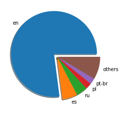

```python
plt.pie(pie_data['Language Code'], labels=pie_data['index'], explode=[0.1, 0,0,0,0,0], shadow=True)
plt.show()
```

The pie chart shows that English wikis comprise a significant percentage of all Fandom Wikis. Hence, English Wikis should be sufficiently representative of all Fandom wikis.

#### Evaluation of Dataset with article count 100-1000

We will further evaluate the subset of data taken from all English wikis. To minimise outliers in wiki size, wikis with 100-1000 articles were chosen for the final dataset. We will first evaluate this subset by comparing it against the overrall English wiki count.

```python
fandom_wikis_stats_en_stacked_genre = pd.read_csv('data/fandom_wikis_stats_en_stacked_genre.csv', encoding='utf-16')
sentiment_extlink_checkpt = pd.read_csv('data/sentiment_extlink_checkpt.csv')
```

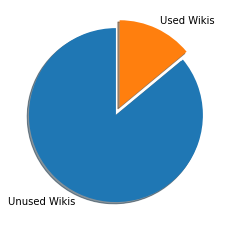

```python
plt.pie([fandom_wikis_stats_en_stacked_genre['Domain'].count(), sentiment_extlink_checkpt['Domain'].count(
)], explode=[0, 0.1], labels=['Unused Wikis', 'Used Wikis'], shadow=True, startangle=90)
plt.show()
```

As can be observed in the graph, the number of used wikis only comprises a small percentage of all English wikis. Hence, it is possible that this subset is not representative of all Fandom wikis. Further analysis is required.

#### Genre Frequency

Hence, we will compare the frequency of genre for both the overrall English wiki dataset, and the subset that is being used.

```python
used = fandom_wikis_stats_en_stacked_genre.loc[fandom_wikis_stats_en_stacked_genre['Domain'].isin(sentiment_extlink_checkpt['Domain'])].reset_index(drop=True).loc[:, ['Domain', 'Genre']]['Genre'].apply(lambda x: x.split(', ')).explode('Genre').value_counts().reset_index()
unused = fandom_wikis_stats_en_stacked_genre['Genre'].apply(lambda x: x.split(', ')).explode('Genre').value_counts().reset_index()
used['IsUsed'] = True
unused['IsUsed'] = False
genre_compare = pd.concat([used, unused])
genre_compare.columns = ['Genre', 'Count', 'IsUsed']
genre_compare
```

|  | Genre | Count | IsUsed |
| --- | --- | --- | --- |
| 0 | Games | 11418 | True |
| 1 | Entertainment | 5902 | True |
| 2 | TV | 4711 | True |
| 3 | Books | 1735 | True |
| 4 | Music | 1364 | True |
| 5 | Movies | 1260 | True |
| 6 | Comics | 987 | True |
| 7 | Anime | 925 | True |
| 8 | Humor | 453 | True |
| 9 | Sports | 261 | True |
| 10 | Toys | 256 | True |
| 11 | Travel | 138 | True |
| 0 | Games | 74836 | False |
| 1 | Entertainment | 29442 | False |
| 2 | TV | 24836 | False |
| 3 | Books | 12614 | False |
| 4 | Music | 10862 | False |
| 5 | Movies | 8564 | False |
| 6 | Comics | 7370 | False |
| 7 | Anime | 4922 | False |
| 8 | Humor | 3323 | False |
| 9 | Sports | 1365 | False |
| 10 | Toys | 1298 | False |
| 11 | Travel | 960 | False |

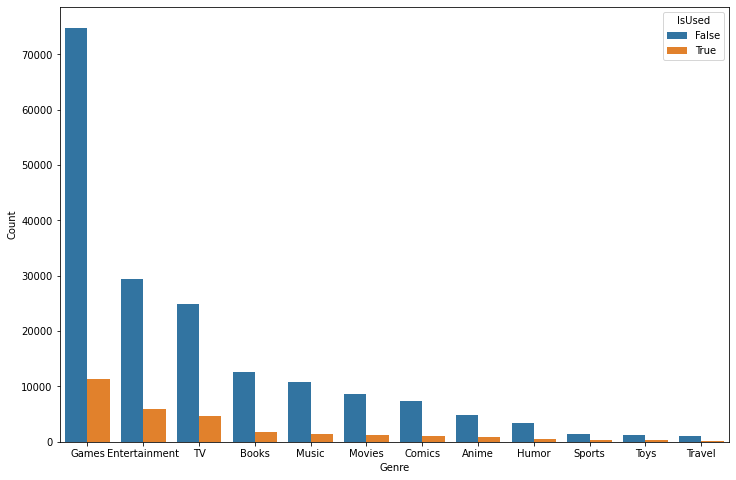

```python
plt.figure(figsize=(12,8))
sns.barplot(data=genre_compare, x='Genre', y='Count', hue='IsUsed')
```

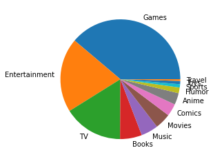

```python
plt.pie(used['Genre'], labels=used['index'])
plt.show()
```

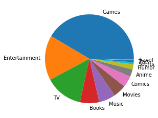

```python
plt.pie(unused['Genre'], labels=used['index'])
plt.show()
```

As can be seen from the graph and pie charts, both used and unused subsets of the English wiki dataset have approximately the same Genre frequencies. Hence, the used dataset is representative of the overrall dataset.

### Q1 What are the correlations betweeen emotional weight of wiki text and the positivity/negativity of the same text?

First, each wiki will have its wikitext parsed to obtain plaintext using WTP, an open source library for parsing Mediawiki's wikitext format. The resulting plaintext is then cleaned with string manipulation, and tokenized. Each token is then mapped to its relevant emotional weight using the NRC dataset, and summed up with respect to word frequency to obtain the overrall emotional weight of each wiki. each emotional weight is then divided by wordcount to obtain a percentage weightage, and the resulting data is passed to a regression model to obtain an equation representing the correleations between emotional weightage and the wiki's positivity/negativity.

We will be using the sentiment + external link wiki dataset to answer this question. the external links column is parsed to lists.

```python
sentiment_extlink_df = pd.read_csv('data/sentiment_extlink_checkpt.csv')
sentiment_extlink_df['ext_links'] = sentiment_extlink_df['ext_links'].apply(ast.literal_eval)
sentiment_extlink_df
```

|  | Domain | wordcount | anger | anticipation | disgust | fear | joy | negative | positive | sadness | surprise | trust | ext_links |
| --- | --- | --- | --- | --- | --- | --- | --- | --- | --- | --- | --- | --- | --- |
| 0 | https://0123456p.fandom.com/api.php | 556 | 6 | 17 | 4 | 9 | 18 | 11 | 39 | 13 | 4 | 16 | [] |
| 1 | https://07ghost.fandom.com/api.php | 4802 | 308 | 294 | 164 | 456 | 296 | 452 | 614 | 294 | 99 | 341 | [wikipedia.org] |
| 2 | https://0ad.fandom.com/api.php | 1842 | 81 | 82 | 15 | 115 | 68 | 114 | 190 | 31 | 24 | 122 | [wildfiregames.com, dropbox.com] |
| 3 | https://0b0t.fandom.com/api.php | 2225 | 74 | 62 | 49 | 104 | 52 | 171 | 212 | 73 | 22 | 123 | [discord.gg, reddit.com, youtube.com, imgur.co... |
| 4 | https://0x10cuniverse.fandom.com/api.php | 705 | 19 | 25 | 7 | 23 | 15 | 32 | 97 | 11 | 5 | 72 | [] |
| ... | ... | ... | ... | ... | ... | ... | ... | ... | ... | ... | ... | ... | ... |
| 24239 | https://zsf.fandom.com/api.php | 6226 | 428 | 231 | 75 | 625 | 204 | 686 | 881 | 263 | 179 | 342 | [] |
| 24240 | https://zt2-machinima-databanks.fandom.com/api... | 1425 | 52 | 57 | 38 | 110 | 47 | 101 | 114 | 52 | 39 | 88 | [google.com, inducks.org] |
| 24241 | https://zt2modding.fandom.com/api.php | 1369 | 5 | 15 | 6 | 36 | 19 | 43 | 97 | 12 | 4 | 40 | [] |
| 24242 | https://zuda.fandom.com/api.php | 1229 | 42 | 69 | 30 | 79 | 41 | 94 | 110 | 36 | 40 | 52 | [] |
| 24243 | https://zurrialmultiverse.fandom.com/api.php | 1632 | 104 | 59 | 72 | 142 | 59 | 168 | 180 | 59 | 32 | 68 | [] |

24244 rows × 13 columns

Emotion values are kept and divided by total wordcount of each wiki respectively.

```python
maldata = sentiment_extlink_df.loc[:, ['anger', 'anticipation', 'disgust', 'fear', 'joy', 'negative',
          'positive', 'sadness', 'surprise', 'trust']].div(sentiment_extlink_df['wordcount'], axis=0)
maldata
```

|  | anger | anticipation | disgust | fear | joy | negative | positive | sadness | surprise | trust |
| --- | --- | --- | --- | --- | --- | --- | --- | --- | --- | --- |
| 0 | 0.010791 | 0.030576 | 0.007194 | 0.016187 | 0.032374 | 0.019784 | 0.070144 | 0.023381 | 0.007194 | 0.028777 |
| 1 | 0.064140 | 0.061224 | 0.034152 | 0.094960 | 0.061641 | 0.094127 | 0.127863 | 0.061224 | 0.020616 | 0.071012 |
| 2 | 0.043974 | 0.044517 | 0.008143 | 0.062432 | 0.036916 | 0.061889 | 0.103149 | 0.016830 | 0.013029 | 0.066232 |
| 3 | 0.033258 | 0.027865 | 0.022022 | 0.046742 | 0.023371 | 0.076854 | 0.095281 | 0.032809 | 0.009888 | 0.055281 |
| 4 | 0.026950 | 0.035461 | 0.009929 | 0.032624 | 0.021277 | 0.045390 | 0.137589 | 0.015603 | 0.007092 | 0.102128 |
| ... | ... | ... | ... | ... | ... | ... | ... | ... | ... | ... |
| 24239 | 0.068744 | 0.037102 | 0.012046 | 0.100385 | 0.032766 | 0.110183 | 0.141503 | 0.042242 | 0.028750 | 0.054931 |
| 24240 | 0.036491 | 0.040000 | 0.026667 | 0.077193 | 0.032982 | 0.070877 | 0.080000 | 0.036491 | 0.027368 | 0.061754 |
| 24241 | 0.003652 | 0.010957 | 0.004383 | 0.026297 | 0.013879 | 0.031410 | 0.070855 | 0.008766 | 0.002922 | 0.029218 |
| 24242 | 0.034174 | 0.056143 | 0.024410 | 0.064280 | 0.033360 | 0.076485 | 0.089504 | 0.029292 | 0.032547 | 0.042311 |
| 24243 | 0.063725 | 0.036152 | 0.044118 | 0.087010 | 0.036152 | 0.102941 | 0.110294 | 0.036152 | 0.019608 | 0.041667 |

24244 rows × 10 columns

An MLRM to predict positivity is generated as seen below

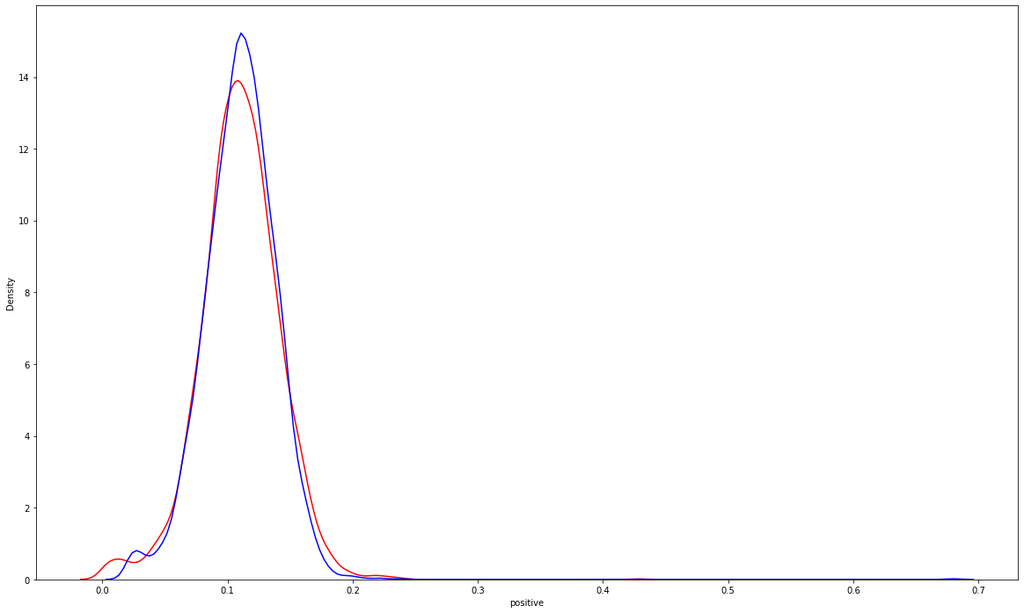

```python
mlm = LinearRegression()
X_train, X_test, y_train, y_test = train_test_split(maldata[['anger', 'anticipation', 'disgust', 'fear', 'joy', 'sadness', 'surprise', 'trust']], maldata['positive'], test_size=0.2, random_state=0)
mlm.fit(X_train, y_train)
yhat= mlm.predict(X_test)
yhat
plt.figure(figsize=(20,12))
sns.kdeplot(y_test, color='r', label='Actual Value')
sns.kdeplot(yhat,  color='b', label='Fitted Value')
```

```python
print(f'yhat={mlm.intercept_} + {mlm.coef_[0]} anger + {mlm.coef_[1]} anticipation + {mlm.coef_[2]} disgust + {mlm.coef_[3]} fear + {mlm.coef_[4]} joy + {mlm.coef_[5]} sadness + {mlm.coef_[6]} surprise + {mlm.coef_[7]} trust')
```

```
yhat=0.020188826328519566 + 0.18500527911704165 anger + 0.2660235617807205 anticipation + -0.060239690173683025 disgust + 0.1411132471079471 fear + 0.6621365818401261 joy + -0.37150011959429885 sadness + -0.07617231284204737 surprise + 0.687216960987133 trust
```

The fitted equation appears to have little deviation from the actual data. It can be observed from this equation that anger, anticipation and fear have a positive relatively small coefficient, joy and trust have a positive relatively large coefficient. This implies that anger, anticipation, and fear are minor contributors towards positivity, while joy and trust are strong contributors towards positivity. Disgust and Surprise have a negative relatively small coefficient, while sadness has a negative relatively large coefficient. This implies that Disgust and Surprise work against positivity to a small extent, while Sadness decrements positivity the most.

It is particularly surprising that emotions such as anger and fear contribute towards positivity. Some possible reasons for this could be that terms closely related to anger and fear, can also be phrased in a positive manner. Sadness being the greatest negator of positivity is as expected. However, trust appears to be the greatest contributor towards positivity, as opposed to joy. A likely explanation for this is that Joy can be expressed in a negative light, such as sadism, while Trust is more often a positive emotion.

An MLRM to predict negativity is generated as seen below

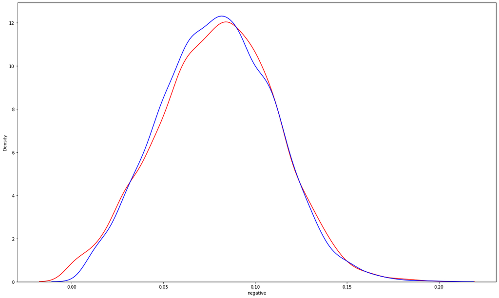

```python
mlm2 = LinearRegression()
X_train2, X_test2, y_train2, y_test2 = train_test_split(maldata[['anger', 'anticipation', 'disgust', 'fear', 'joy', 'sadness', 'surprise', 'trust']], maldata['negative'], test_size=0.2, random_state=0)
mlm2.fit(X_train2, y_train2)
yhat2 = mlm2.predict(X_test2)
yhat2
plt.figure(figsize=(20,12))
sns.kdeplot(y_test2, color='r', label='Actual Value')
sns.kdeplot(yhat2,  color='b', label='Fitted Value')
```

```python
print(f'yhat={mlm2.intercept_} + {mlm2.coef_[0]} anger + {mlm2.coef_[1]} anticipation + {mlm2.coef_[2]} disgust + {mlm2.coef_[3]} fear + {mlm2.coef_[4]} joy + {mlm2.coef_[5]} sadness + {mlm2.coef_[6]} surprise + {mlm2.coef_[7]} trust')
```

```
yhat=0.00888615096654366 + 0.47087014369639413 anger + 0.08698425919861141 anticipation + 0.4007340141807568 disgust + 0.34573851313544723 fear + -0.13350281959507235 joy + 0.4721731812740334 sadness + 0.09866755810590114 surprise + -0.01384486918362654 trust
```

The fitted equation appears to have little deviation from the actual data. It can be observed from this equation that anticipation and surprise have a positive relatively small coefficient, and anger, disgust, fear, sadness have a positive relatively large coefficient. This implies that anticipation and surprise are minor contributors towards negativity, while anger, disgust, fear, sadness are strong contributors towards negativity. Trust has a negative relatively small coefficient, while joy has a negative relatively large coefficient. This implies that trust work against negativity to a small extent, while joy decrements negativity the most.

Interestingly, these results do not appear to be the inverse of what is observed for positivity. Hence, we can conclude from this that positivity and negativity are not exact polar opposites of each other in terms of emotions. There appears to be no emotions that greatly work against negativity, with joy having the highest magnitude negative coefficient. of -0.13. This implies that negative text containing phrases that imply posivitity, will remain largely negative.

As an extension to this question, An MLRM to predict anger is generated as seen below

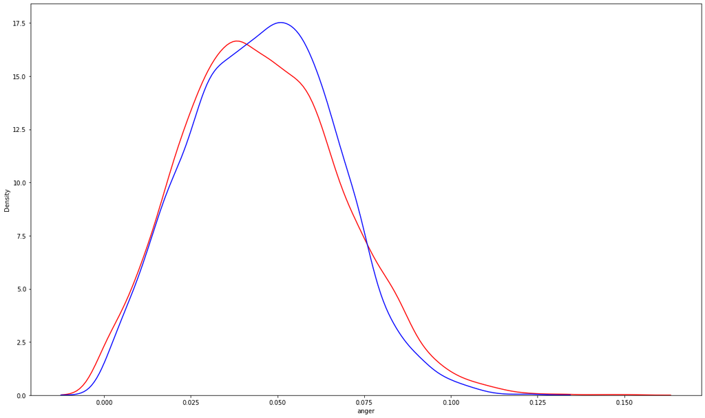

```python
mlm3 = LinearRegression()
X_train3, X_test3, y_train3, y_test3 = train_test_split(maldata[['anticipation', 'disgust', 'fear', 'joy', 'sadness', 'surprise', 'trust']], maldata['anger'], test_size=0.2, random_state=0)
mlm3.fit(X_train3, y_train3)
yhat3 = mlm3.predict(X_test3)
yhat3
plt.figure(figsize=(20,12))
sns.kdeplot(y_test3, color='r', label='Actual Value')
sns.kdeplot(yhat3,  color='b', label='Fitted Value')
```

```python
print(f'yhat={mlm3.intercept_} + {mlm3.coef_[0]} anticipation + {mlm3.coef_[1]} disgust + {mlm3.coef_[2]} fear + {mlm3.coef_[3]} joy + {mlm3.coef_[4]} sadness + {mlm3.coef_[5]} surprise + {mlm3.coef_[6]} trust')
```

```
yhat=0.0011258610623556403 + -0.07092094435737664 anticipation + 0.15268724920672172 disgust + 0.6021373447985878 fear + -0.044040220722326884 joy + 0.06293033823567395 sadness + 0.2484674537708601 surprise + 0.0007937735974912763 trust
```

The fitted equation appears to have little deviation from the actual data. It can be observed from this equation that sadness and trust have a positive relatively small coefficient, and disgust, fear, surprise have a positive relatively large coefficient. This implies that sadness and trust are minor contributors towards anger, while disgust, fear, surprise are strong contributors towards anger. anticipation and joy have a negative relatively small coefficient. This implies that anticipation and joy work against anger to a small extent.

There appears to be no major contributor towards decrementing anger. This implies that text that indicates anger will not decrease its emotional vector significantly with the addition of other words that indicate other emotions.

### Q2 Which external domains are commonly used for each genre of wiki?

First, we will obtain the top used external link of each domain, and generate a heatmap consisting of the frequency of each external link against wiki genre. We will then do a 2nd similar heatmap comparison, but with the top 5 external links.

```python
sentiment_extlink_df = pd.read_csv('data/sentiment_extlink_checkpt.csv')
haslink_sentiment_extlink_df = sentiment_extlink_df.loc[sentiment_extlink_df['ext_links']!='[]'].reset_index(drop=True)
haslink_sentiment_extlink_df
```

|  | Domain | wordcount | anger | anticipation | disgust | fear | joy | negative | positive | sadness | surprise | trust | ext_links |
| --- | --- | --- | --- | --- | --- | --- | --- | --- | --- | --- | --- | --- | --- |
| 0 | https://07ghost.fandom.com/api.php | 4802 | 308 | 294 | 164 | 456 | 296 | 452 | 614 | 294 | 99 | 341 | ['wikipedia.org'] |
| 1 | https://0ad.fandom.com/api.php | 1842 | 81 | 82 | 15 | 115 | 68 | 114 | 190 | 31 | 24 | 122 | ['wildfiregames.com', 'dropbox.com'] |
| 2 | https://0b0t.fandom.com/api.php | 2225 | 74 | 62 | 49 | 104 | 52 | 171 | 212 | 73 | 22 | 123 | ['discord.gg', 'reddit.com', 'youtube.com', 'i... |
| 3 | https://100-things.fandom.com/api.php | 1614 | 23 | 73 | 3 | 29 | 50 | 49 | 222 | 24 | 22 | 102 | ['doi.org', 'semanticscholar.org', 'youtube.co... |
| 4 | https://1000points.fandom.com/api.php | 4189 | 209 | 277 | 120 | 226 | 296 | 317 | 562 | 196 | 139 | 418 | ['fandom.com'] |
| ... | ... | ... | ... | ... | ... | ... | ... | ... | ... | ... | ... | ... | ... |
| 11586 | https://zootycoon.fandom.com/api.php | 3943 | 93 | 118 | 90 | 167 | 103 | 207 | 311 | 71 | 59 | 199 | ['facebook.com', 'youtube.com'] |
| 11587 | https://zornpedia.fandom.com/api.php | 3793 | 266 | 132 | 104 | 366 | 70 | 453 | 304 | 156 | 102 | 161 | ['wikimedia.org', 'obsidian.net', 'fandom.com'... |
| 11588 | https://zorro.fandom.com/api.php | 2336 | 129 | 195 | 43 | 191 | 139 | 213 | 325 | 101 | 99 | 251 | ['lambiek.net', 'proquest.com'] |
| 11589 | https://zotiyac.fandom.com/api.php | 1776 | 73 | 87 | 64 | 103 | 82 | 145 | 156 | 76 | 40 | 58 | ['soundcloud.com', 'twitter.com', 'youtube.com... |
| 11590 | https://zt2-machinima-databanks.fandom.com/api... | 1425 | 52 | 57 | 38 | 110 | 47 | 101 | 114 | 52 | 39 | 88 | ['google.com', 'inducks.org'] |

11591 rows × 13 columns

We will be using our stacked genre english wiki dataset to label the wikis by genre. Unnecessary columns are dropped, and the Genre columns is changed to a column of lists.

```python
fandom_wikis_stats_en_stacked_genre = pd.read_csv('data/fandom_wikis_stats_en_stacked_genre.csv', encoding='utf-16')
lim = fandom_wikis_stats_en_stacked_genre.loc[fandom_wikis_stats_en_stacked_genre['Domain'].isin(sentiment_extlink_df['Domain'])].reset_index(drop=True).loc[:, ['Domain', 'Genre']]
lim['Genre'] = lim['Genre'].apply(lambda x: x.split(', '))
lim
```

|  | Domain | Genre |
| --- | --- | --- |
| 0 | https://0123456p.fandom.com/api.php | [Games] |
| 1 | https://07ghost.fandom.com/api.php | [Entertainment, Anime] |
| 2 | https://0ad.fandom.com/api.php | [Games] |
| 3 | https://0b0t.fandom.com/api.php | [Games] |
| 4 | https://0x10cuniverse.fandom.com/api.php | [Games] |
| ... | ... | ... |
| 23343 | https://zsf.fandom.com/api.php | [Games] |
| 23344 | https://zt2-machinima-databanks.fandom.com/api... | [Entertainment, Movies] |
| 23345 | https://zt2modding.fandom.com/api.php | [Games] |
| 23346 | https://zuda.fandom.com/api.php | [Comics] |
| 23347 | https://zurrialmultiverse.fandom.com/api.php | [Games] |

23348 rows × 2 columns

The genres are then merged into our external link dataset. The top 10 external links are determined, and other links are converted to a placeholder 'misc.extlink'.

```python
lim_sentiment_extlink_df = haslink_sentiment_extlink_df.merge(lim, how='inner').loc[:, ['Domain', 'Genre', 'ext_links']]
top_extlinks = lim_sentiment_extlink_df['ext_links'].apply(lambda x: ast.literal_eval(x)[0])
top_overrall_extlinks = top_extlinks.value_counts().head(10).index.to_list()
top_extlinks.loc[~top_extlinks.isin(top_overrall_extlinks)] = 'misc.extlink'
lim_sentiment_extlink_df['top_extlink'] = top_extlinks
lim_sentiment_extlink_df
```

|  | Domain | Genre | ext_links | top_extlink |
| --- | --- | --- | --- | --- |
| 0 | https://07ghost.fandom.com/api.php | [Entertainment, Anime] | ['wikipedia.org'] | wikipedia.org |
| 1 | https://0ad.fandom.com/api.php | [Games] | ['wildfiregames.com', 'dropbox.com'] | misc.extlink |
| 2 | https://0b0t.fandom.com/api.php | [Games] | ['discord.gg', 'reddit.com', 'youtube.com', 'i... | discord.gg |
| 3 | https://100-things.fandom.com/api.php | [Entertainment, Books] | ['doi.org', 'semanticscholar.org', 'youtube.co... | misc.extlink |
| 4 | https://1000points.fandom.com/api.php | [Humor, TV] | ['fandom.com'] | fandom.com |
| ... | ... | ... | ... | ... |
| 11195 | https://zootycoon.fandom.com/api.php | [Games] | ['facebook.com', 'youtube.com'] | facebook.com |
| 11196 | https://zornpedia.fandom.com/api.php | [Games] | ['wikimedia.org', 'obsidian.net', 'fandom.com'... | misc.extlink |
| 11197 | https://zorro.fandom.com/api.php | [Movies] | ['lambiek.net', 'proquest.com'] | misc.extlink |
| 11198 | https://zotiyac.fandom.com/api.php | [Entertainment, Music] | ['soundcloud.com', 'twitter.com', 'youtube.com... | misc.extlink |
| 11199 | https://zt2-machinima-databanks.fandom.com/api... | [Entertainment, Movies] | ['google.com', 'inducks.org'] | google.com |

11200 rows × 4 columns

Frequencies of the top external link for each wiki are then obtained as shown, categorized by Genre.

```python
extlink_count = lim_sentiment_extlink_df.explode('Genre', ignore_index=True).groupby('Genre')['top_extlink'].value_counts().unstack().T
extlink_count
```

| Genre top_extlink | Anime | Books | Comics | Entertainment | Games | Humor | Movies | Music | Sports | TV | Toys | Travel |
| --- | --- | --- | --- | --- | --- | --- | --- | --- | --- | --- | --- | --- |
| discord.gg | 11.0 | 9.0 | 2.0 | 25.0 | 181.0 | 5.0 | 1.0 | 4.0 | NaN | 16.0 | 2.0 | NaN |
| facebook.com | 1.0 | 27.0 | 16.0 | 82.0 | 202.0 | 4.0 | 12.0 | 28.0 | 7.0 | 69.0 | 3.0 | 8.0 |
| fandom.com | 82.0 | 107.0 | 61.0 | 403.0 | 921.0 | 33.0 | 87.0 | 72.0 | 5.0 | 278.0 | 19.0 | 4.0 |
| google.com | 7.0 | 18.0 | 6.0 | 82.0 | 275.0 | 7.0 | 25.0 | 15.0 | 5.0 | 75.0 | 3.0 | 2.0 |
| misc.extlink | 229.0 | 386.0 | 159.0 | 1367.0 | 2350.0 | 96.0 | 221.0 | 331.0 | 38.0 | 909.0 | 39.0 | 37.0 |
| roblox.com | NaN | NaN | NaN | NaN | 193.0 | NaN | 1.0 | 1.0 | NaN | 1.0 | NaN | NaN |
| twitter.com | 86.0 | 30.0 | 33.0 | 303.0 | 278.0 | 16.0 | 32.0 | 79.0 | 2.0 | 208.0 | 5.0 | 3.0 |
| wikia.com | 5.0 | 24.0 | 16.0 | 71.0 | 113.0 | 4.0 | 10.0 | 5.0 | NaN | 38.0 | 5.0 | NaN |
| wikipedia.org | 36.0 | 71.0 | 22.0 | 200.0 | 160.0 | 12.0 | 41.0 | 26.0 | 5.0 | 114.0 | 2.0 | 3.0 |
| youtu.be | 9.0 | 8.0 | 3.0 | 77.0 | 146.0 | 9.0 | 13.0 | 30.0 | 1.0 | 76.0 | 7.0 | 2.0 |
| youtube.com | 36.0 | 57.0 | 43.0 | 461.0 | 797.0 | 74.0 | 120.0 | 151.0 | 16.0 | 444.0 | 21.0 | 2.0 |

The top external link values are then divided by the total external links for that genre, to obtain a ratio value.

```python
extlink_count_ratio = extlink_count/extlink_count.sum(axis=0)
extlink_count_ratio
```

| Genre top_extlink | Anime | Books | Comics | Entertainment | Games | Humor | Movies | Music | Sports | TV | Toys | Travel |
| --- | --- | --- | --- | --- | --- | --- | --- | --- | --- | --- | --- | --- |
| discord.gg | 0.021912 | 0.012212 | 0.005540 | 0.008141 | 0.032229 | 0.019231 | 0.001776 | 0.005391 | NaN | 0.007181 | 0.018868 | NaN |
| facebook.com | 0.001992 | 0.036635 | 0.044321 | 0.026701 | 0.035969 | 0.015385 | 0.021314 | 0.037736 | 0.088608 | 0.030969 | 0.028302 | 0.131148 |
| fandom.com | 0.163347 | 0.145183 | 0.168975 | 0.131228 | 0.163996 | 0.126923 | 0.154529 | 0.097035 | 0.063291 | 0.124776 | 0.179245 | 0.065574 |
| google.com | 0.013944 | 0.024423 | 0.016620 | 0.026701 | 0.048967 | 0.026923 | 0.044405 | 0.020216 | 0.063291 | 0.033662 | 0.028302 | 0.032787 |
| misc.extlink | 0.456175 | 0.523745 | 0.440443 | 0.445132 | 0.418447 | 0.369231 | 0.392540 | 0.446092 | 0.481013 | 0.407989 | 0.367925 | 0.606557 |
| roblox.com | NaN | NaN | NaN | NaN | 0.034366 | NaN | 0.001776 | 0.001348 | NaN | 0.000449 | NaN | NaN |
| twitter.com | 0.171315 | 0.040706 | 0.091413 | 0.098665 | 0.049501 | 0.061538 | 0.056838 | 0.106469 | 0.025316 | 0.093357 | 0.047170 | 0.049180 |
| wikia.com | 0.009960 | 0.032564 | 0.044321 | 0.023120 | 0.020121 | 0.015385 | 0.017762 | 0.006739 | NaN | 0.017056 | 0.047170 | NaN |
| wikipedia.org | 0.071713 | 0.096336 | 0.060942 | 0.065125 | 0.028490 | 0.046154 | 0.072824 | 0.035040 | 0.063291 | 0.051167 | 0.018868 | 0.049180 |
| youtu.be | 0.017928 | 0.010855 | 0.008310 | 0.025073 | 0.025997 | 0.034615 | 0.023091 | 0.040431 | 0.012658 | 0.034111 | 0.066038 | 0.032787 |
| youtube.com | 0.071713 | 0.077341 | 0.119114 | 0.150114 | 0.141916 | 0.284615 | 0.213144 | 0.203504 | 0.202532 | 0.199282 | 0.198113 | 0.032787 |

Below is a heatmap of the frequency of most used domain by wiki, against wiki genre.

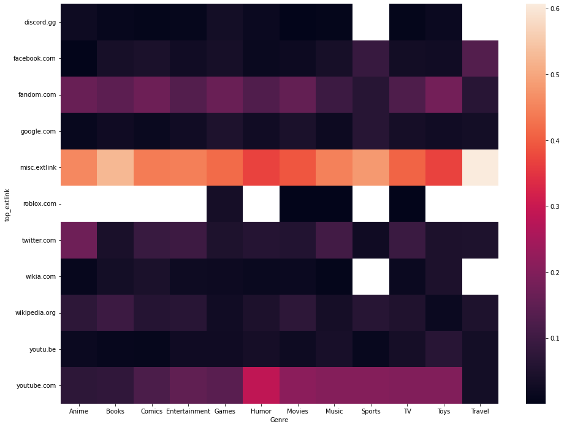

```python
plt.figure(figsize=(16,12))
sns.heatmap(extlink_count_ratio)
```

A graph of top external links per wiki against frequency is also generated.

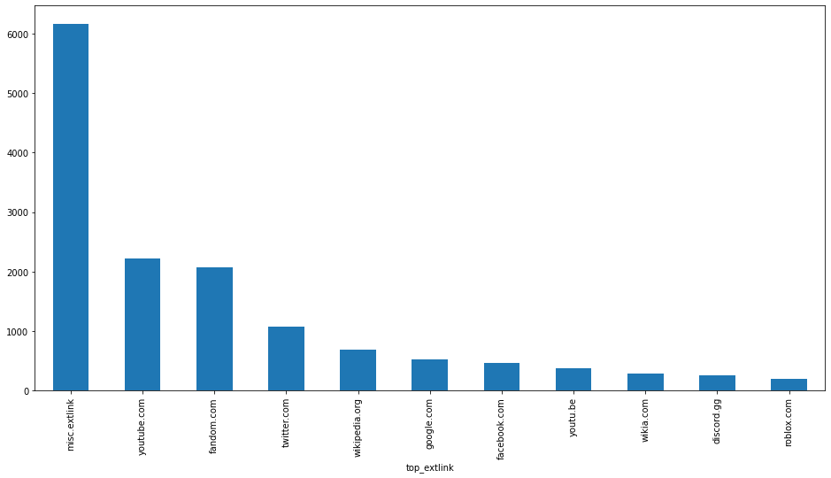

```python
plt.figure(figsize=(16,8))
extlink_count.sum(axis=1).sort_values(ascending=False).plot(kind='bar')
plt.show()
```

It can be seen from this graph that Miscellaneous external links greatly outnumber the top 10 external links.

Overrall, the above heatmap has proved insufficient for answering the question. There is a significant number of missing data in the heatmap, and many results are inconclusive. The density of miscellaneous links also far exceeds the links being analysed in the heatmap. Hence, a heatmap is constructed for the top 5 external links per wiki to supplement the first heatmap. Similar data processing is performed on the dataset as with the first heatmap.

```python
expl_sentiment_extlink_df = lim_sentiment_extlink_df.explode('Genre', ignore_index=True).drop('top_extlink', axis=1).explode('ext_links',ignore_index=True)
expl_sentiment_extlink_df
```

|  | Domain | Genre | ext_links |
| --- | --- | --- | --- |
| 0 | https://07ghost.fandom.com/api.php | Entertainment | wikipedia.org |
| 1 | https://07ghost.fandom.com/api.php | Anime | wikipedia.org |
| 2 | https://0ad.fandom.com/api.php | Games | wildfiregames.com |
| 3 | https://0ad.fandom.com/api.php | Games | dropbox.com |
| 4 | https://0b0t.fandom.com/api.php | Games | discord.gg |
| ... | ... | ... | ... |
| 38870 | https://zotiyac.fandom.com/api.php | Music | youtu.be |
| 38871 | https://zt2-machinima-databanks.fandom.com/api... | Entertainment | google.com |
| 38872 | https://zt2-machinima-databanks.fandom.com/api... | Entertainment | inducks.org |
| 38873 | https://zt2-machinima-databanks.fandom.com/api... | Movies | google.com |
| 38874 | https://zt2-machinima-databanks.fandom.com/api... | Movies | inducks.org |

38875 rows × 3 columns

```python
expl_extlink_count = expl_sentiment_extlink_df.groupby('Genre')['ext_links'].value_counts().unstack().T.dropna()
expl_extlink_count
```

| Genre ext_links | Anime | Books | Comics | Entertainment | Games | Humor | Movies | Music | Sports | TV | Toys | Travel |
| --- | --- | --- | --- | --- | --- | --- | --- | --- | --- | --- | --- | --- |
| archive.org | 17.0 | 22.0 | 16.0 | 145.0 | 187.0 | 10.0 | 34.0 | 53.0 | 1.0 | 139.0 | 6.0 | 6.0 |
| co.uk | 5.0 | 26.0 | 4.0 | 89.0 | 46.0 | 13.0 | 24.0 | 29.0 | 2.0 | 71.0 | 3.0 | 6.0 |
| deviantart.com | 6.0 | 42.0 | 22.0 | 111.0 | 143.0 | 7.0 | 15.0 | 17.0 | 1.0 | 76.0 | 1.0 | 1.0 |
| discord.gg | 27.0 | 18.0 | 15.0 | 90.0 | 590.0 | 6.0 | 7.0 | 18.0 | 1.0 | 48.0 | 4.0 | 2.0 |
| facebook.com | 10.0 | 56.0 | 32.0 | 235.0 | 471.0 | 26.0 | 41.0 | 77.0 | 15.0 | 188.0 | 7.0 | 14.0 |
| fandom.com | 133.0 | 180.0 | 92.0 | 697.0 | 1588.0 | 58.0 | 143.0 | 127.0 | 11.0 | 490.0 | 34.0 | 7.0 |
| google.com | 22.0 | 51.0 | 20.0 | 211.0 | 740.0 | 21.0 | 47.0 | 53.0 | 9.0 | 186.0 | 8.0 | 2.0 |
| instagram.com | 8.0 | 27.0 | 16.0 | 240.0 | 119.0 | 19.0 | 30.0 | 100.0 | 1.0 | 167.0 | 8.0 | 4.0 |
| nocookie.net | 14.0 | 13.0 | 10.0 | 87.0 | 181.0 | 6.0 | 20.0 | 12.0 | 2.0 | 81.0 | 7.0 | 1.0 |
| reddit.com | 15.0 | 27.0 | 11.0 | 86.0 | 306.0 | 9.0 | 9.0 | 22.0 | 2.0 | 38.0 | 1.0 | 1.0 |
| soundcloud.com | 6.0 | 21.0 | 9.0 | 90.0 | 133.0 | 10.0 | 7.0 | 64.0 | 2.0 | 37.0 | 1.0 | 1.0 |
| twitter.com | 155.0 | 75.0 | 68.0 | 705.0 | 810.0 | 51.0 | 95.0 | 202.0 | 10.0 | 480.0 | 16.0 | 7.0 |
| wikipedia.org | 89.0 | 123.0 | 51.0 | 444.0 | 425.0 | 25.0 | 86.0 | 86.0 | 9.0 | 260.0 | 6.0 | 10.0 |
| youtu.be | 32.0 | 29.0 | 15.0 | 240.0 | 580.0 | 39.0 | 44.0 | 96.0 | 5.0 | 215.0 | 19.0 | 3.0 |
| youtube.com | 102.0 | 128.0 | 85.0 | 931.0 | 1783.0 | 132.0 | 184.0 | 341.0 | 25.0 | 785.0 | 37.0 | 11.0 |

```python
expl_extlink_count_ratio = expl_extlink_count/expl_extlink_count.sum(axis=0)
expl_extlink_count_ratio
```

| Genre ext_links | Anime | Books | Comics | Entertainment | Games | Humor | Movies | Music | Sports | TV | Toys | Travel |
| --- | --- | --- | --- | --- | --- | --- | --- | --- | --- | --- | --- | --- |
| archive.org | 0.026521 | 0.026253 | 0.034335 | 0.032947 | 0.023081 | 0.023148 | 0.043257 | 0.040864 | 0.010417 | 0.042625 | 0.037975 | 0.078947 |
| co.uk | 0.007800 | 0.031026 | 0.008584 | 0.020223 | 0.005678 | 0.030093 | 0.030534 | 0.022359 | 0.020833 | 0.021772 | 0.018987 | 0.078947 |
| deviantart.com | 0.009360 | 0.050119 | 0.047210 | 0.025222 | 0.017650 | 0.016204 | 0.019084 | 0.013107 | 0.010417 | 0.023306 | 0.006329 | 0.013158 |
| discord.gg | 0.042122 | 0.021480 | 0.032189 | 0.020450 | 0.072822 | 0.013889 | 0.008906 | 0.013878 | 0.010417 | 0.014719 | 0.025316 | 0.026316 |
| facebook.com | 0.015601 | 0.066826 | 0.068670 | 0.053397 | 0.058134 | 0.060185 | 0.052163 | 0.059368 | 0.156250 | 0.057651 | 0.044304 | 0.184211 |
| fandom.com | 0.207488 | 0.214797 | 0.197425 | 0.158373 | 0.196001 | 0.134259 | 0.181934 | 0.097918 | 0.114583 | 0.150261 | 0.215190 | 0.092105 |
| google.com | 0.034321 | 0.060859 | 0.042918 | 0.047944 | 0.091335 | 0.048611 | 0.059796 | 0.040864 | 0.093750 | 0.057038 | 0.050633 | 0.026316 |
| instagram.com | 0.012480 | 0.032220 | 0.034335 | 0.054533 | 0.014688 | 0.043981 | 0.038168 | 0.077101 | 0.010417 | 0.051211 | 0.050633 | 0.052632 |
| nocookie.net | 0.021841 | 0.015513 | 0.021459 | 0.019768 | 0.022340 | 0.013889 | 0.025445 | 0.009252 | 0.020833 | 0.024839 | 0.044304 | 0.013158 |
| reddit.com | 0.023401 | 0.032220 | 0.023605 | 0.019541 | 0.037768 | 0.020833 | 0.011450 | 0.016962 | 0.020833 | 0.011653 | 0.006329 | 0.013158 |
| soundcloud.com | 0.009360 | 0.025060 | 0.019313 | 0.020450 | 0.016416 | 0.023148 | 0.008906 | 0.049345 | 0.020833 | 0.011346 | 0.006329 | 0.013158 |
| twitter.com | 0.241810 | 0.089499 | 0.145923 | 0.160191 | 0.099975 | 0.118056 | 0.120865 | 0.155744 | 0.104167 | 0.147194 | 0.101266 | 0.092105 |
| wikipedia.org | 0.138846 | 0.146778 | 0.109442 | 0.100886 | 0.052456 | 0.057870 | 0.109415 | 0.066307 | 0.093750 | 0.079730 | 0.037975 | 0.131579 |
| youtu.be | 0.049922 | 0.034606 | 0.032189 | 0.054533 | 0.071587 | 0.090278 | 0.055980 | 0.074017 | 0.052083 | 0.065931 | 0.120253 | 0.039474 |
| youtube.com | 0.159126 | 0.152745 | 0.182403 | 0.211543 | 0.220069 | 0.305556 | 0.234097 | 0.262914 | 0.260417 | 0.240724 | 0.234177 | 0.144737 |

Below is a heatmap of the frequency of top 5 used domains by wiki, against wiki genre.

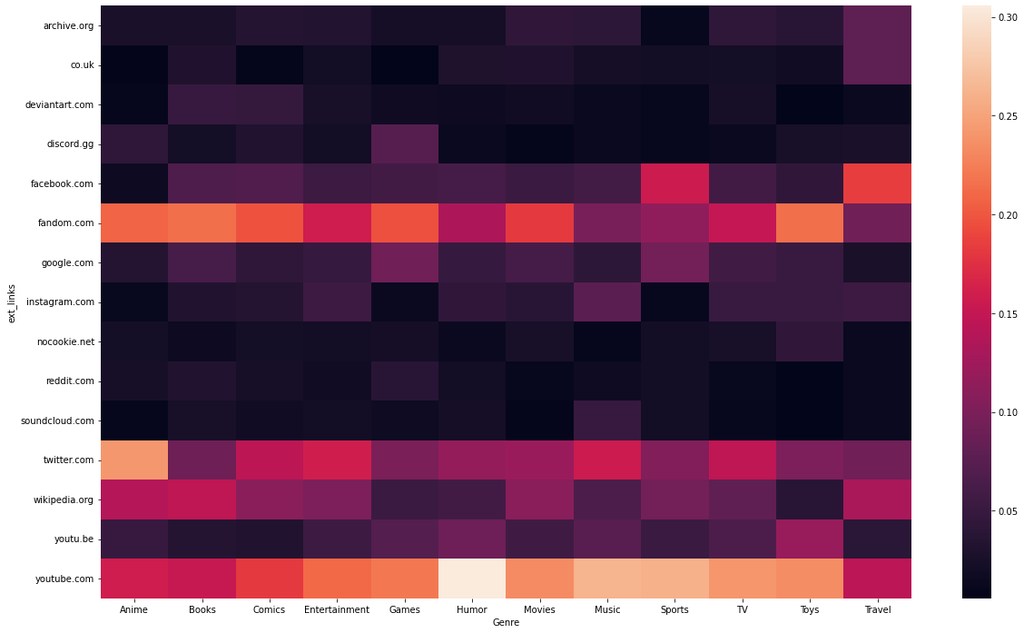

```python
plt.figure(figsize=(20,12))
sns.heatmap(expl_extlink_count_ratio)
```

It can be seen that archive.org and co.uk are highly favoured by Travel Wikis. It is possible that Travel wikis use archive.org as a permenant storage method for Tourism sites. Deviantart is used the most by Books and Comics wikis. As Deviantart is an art blogging platform, this is of no surprise. Games Wikis appear to use discord.gg links the most, with other wikis using discord.gg little, if at all. This is again expected, considering the great number of discord servers related to games that exist. Similarly to the previous heatmap. Facebook appears to be favoured significantly by Sports and Travel Wikis, while being used the least in Anime Wikis. It is also possible that Facebook profiles of sports players are being referenced in these wikis, leading to the high frequency. Fandom.com links are most referenced by Books and Toys wikis. external fandom.com links are often links to other fandom wikis. Hence, we can infer from this that Toy and Books wikis are highly connected with each other. Google.com is most commonly referenced by Sports and Games Wikis. Instagram appears to be most favoured by Music wikis. This makes sense due to the presence of many music artists on Instagram. nocookie.net appears to be the most favoured by Toys wikis. nocookie.net is used by fandom wikis to prevent site cookies from being sent to Fandom servers, hence reducing request size. It is surprising that Toys Genre appears to favour using nocookie.net, as opposed to there being no visible outlier. Reddit appears to be used the most by Games wikis. Similarly to discord, Reddit is often used for discussion of games, so this is again of no surprise. Soundcloud is used the most by Music wikis, which is expected considering Soundcloud is a platform for hosting music. Twitter.com is most favoured by Anime wikis, and by Music, Entertainment, Comics and TV wikis to a smaller extent. Twitter hosts a large variety of content, so it is surprising that Anime appears to be highly prevelant on Twitter. Wikipedia.org is referenced the most by Books Wikis. Youtube's link shortener is most commonly used by Toys wikis, and its full domain is most commonly used by Humor wikis. This is likely due to Youtube being a platform that hosts a large volume of "meme" media. It can be observed that Toys wikis appear to employ "safety nets", with the nocookie request and link shortener. This could be a side effect of trying to appeal to a smaller audience.

### Q3 How has the presence of movies on Fandom changed over time?

First, the timestamps from all Movie wikis are collected into 1 Dataframe, and passed to a KDE plot. Then, each wiki's timestamps will be overlayed using KDE plots.

Timestamps from each wiki article are read into a Dataframe of Series of Timestamps.

```python
timestamps = []
wikis = os.listdir('./data/timestamps')
for i in tqdm(range(len(wikis))):
    timestamps.append([wikis[i][5:-4], pd.read_csv(f'data/timestamps/{wikis[i]}')['Timestamps'].apply(ast.literal_eval).explode().reset_index(drop=True)])
```

```python
timestamp_df = pd.DataFrame(timestamps, columns = ['Domain', 'Timestamps'])
timestamp_df
```

|  | Domain | Timestamps |
| --- | --- | --- |
| 0 | aikatsu-next-melody | 0 2015-04-19T14:33:44Z 1 2015-04-19T... |
| 1 | ageofsigmar | 0 2021-03-30T13:58:10Z 1 2021-03-2... |
| 2 | a-not-so-strict-jjba | 0 2014-01-08T04:14:09Z 1 2014-01-0... |
| 3 | aikidomagazine | 0 2018-05-06T00:07:43Z 1 2018-05-0... |
| 4 | 90scartoons | 0 2018-12-06T04:59:48Z 1 2017-12-2... |
| ... | ... | ... |
| 1255 | apink | 0 2019-03-29T00:14:54Z 1 2019-03-2... |
| 1256 | all-male-characters | 0 2013-07-10T20:19:21Z 1 2013-06-17T... |
| 1257 | aquapets | 0 2022-08-24T01:23:07Z 1 2020-05-0... |
| 1258 | a-change-of-pace-rp | 0 2018-11-19T21:20:28Z 1 2018-11-0... |
| 1259 | adawnoficeandfirerp | 0 2019-02-12T17:18:09Z 1 2019-02-12T... |

1260 rows × 2 columns

The timestamps string are parsed into pandas Timestamp objects.

```python
timestamps_vals = pd.concat(timestamp_df['Timestamps'].to_list()).reset_index(drop=True).apply(lambda x: pd.Timestamp(x))
timestamps_vals
```

```
0         2015-04-19 14:33:44+00:00
1         2015-04-19 14:33:43+00:00
2         2015-04-28 00:50:52+00:00
3         2015-04-20 02:32:10+00:00
4         2015-04-26 15:27:10+00:00
                     ...
3474714   2019-02-12 16:50:51+00:00
3474715   2018-08-26 18:51:02+00:00
3474716   2019-02-12 17:24:47+00:00
3474717   2019-02-12 16:51:03+00:00
3474718   2018-11-11 05:06:35+00:00
Name: Timestamps, Length: 3474719, dtype: datetime64[ns, UTC]
```

```python
timestamps_vals = timestamps_vals.dropna()
timestamps_vals
```

```
0         2015-04-19 14:33:44+00:00
1         2015-04-19 14:33:43+00:00
2         2015-04-28 00:50:52+00:00
3         2015-04-20 02:32:10+00:00
4         2015-04-26 15:27:10+00:00
                     ...
3474714   2019-02-12 16:50:51+00:00
3474715   2018-08-26 18:51:02+00:00
3474716   2019-02-12 17:24:47+00:00
3474717   2019-02-12 16:51:03+00:00
3474718   2018-11-11 05:06:35+00:00
Name: Timestamps, Length: 3474692, dtype: datetime64[ns, UTC]
```

A KDE plot of timestamps against density is generated as follows.

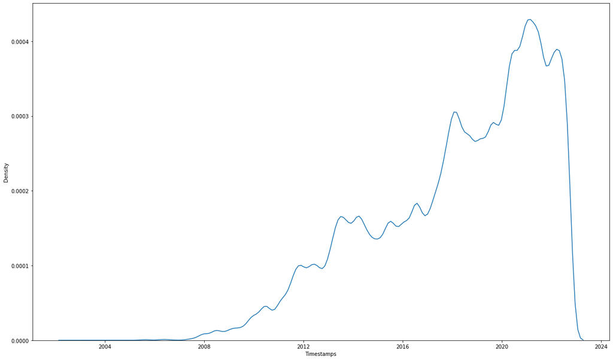

```python
plt.figure(figsize=(20, 12))
sns.kdeplot(data=timestamps_vals)
```

It can be observed from this KDE plot that the edit density of Movie wikis has increased over time. The spikes in edit density appear to follow a cyclic pattern, and hence an autocorrelation plot was employed to find correlation between the wiki edits

```python
timestamps_vals.to_csv('data/wiki_timestamp_db.csv', index=False)
```

```
(-0.05, 0.05)
```

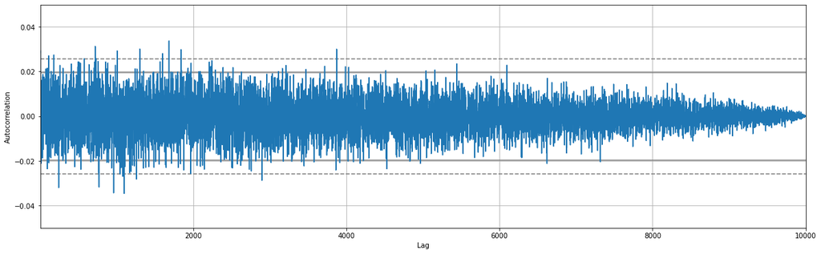

```python
plt.figure(figsize=(20,6))
pd.plotting.autocorrelation_plot(timestamps_vals.sample(n=10000).apply(lambda x:x.timestamp()))
plt.ylim(-0.05,0.05)
```

No obvious pattern can be seen from this correlation graph. Hence, there is likely no correlation between wiki edit timestamps

```
(0.0, 0.01)
```

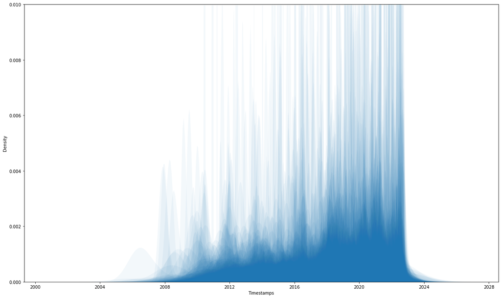

```python
plt.figure(figsize=(20,12))
for i in range(timestamp_df.shape[0]):
    sns.kdeplot(data=timestamp_df.iloc[i, 1].apply(lambda x:pd.Timestamp(x)), fill=True, alpha = 0.05, linewidth=0)
plt.ylim(0,0.01)
```

Similarly to the KDE graph, the density of wiki edits appears to increase. However, it can be noted from this graph that there are a significant number of sharp spikes in wiki activity. This implies that a significant number of Movie wikis experience a number of edits within a short space of time. This would make sense, as Movies rarely change past their release, hence requiring edits to be made only on movie release.

## Conclusion

We can conclude that Fandom's wikitext emotional weightage correlations with positivity/negativity follows what would be expected, with emotions traditionally associated with positivity being represented as such in the regression equation, and vice versa. However, positivity and negativity in text are not polar opposites, and a text's emotions can be interpreted differently based on context, allowing for normally positivt words to also have negative connotations

External Domains also appear to follow expectations, with sites that are closely related to specific genres, being the most referenced by that wiki genre. We can also conclude that there are popular domains such as Soundcloud that are rarely the most used external link in the wiki, but are still present in many wikis. We have also found that sites that typically host diverse content such as Twitter, may be referenced by Fandom sites of specific genres more than others.

Movies have been gaining a larger presence in Fandom over time, but it is worth noting that many of such wikis only experience activity for a short period of time after a movie is released.

## Recommendations or Further Works

I would recommend sites such as Twitter and Youtube to capitalize on the high frequency of their domain being used in Fandom. Fandom could obtain permission from Twitter and Youtube to allow custom embeds in Fandom wikis.

I am looking to expanding the wiki dataset scope of this project in the future, so as to have a larger timestamp dataset for Q3. I would also like to look into the use of Natural Language Processing for developing an AI model with my dataset.

## Appendix

### Wiki Data Structure

In the process of EDA, work was done in analysing how the Fandom wiki dataset is structured. These are the steps that were taken.

```python
utwikirepo = pd.read_csv('data/wikis/wiki_baldis-basics-roblox.csv', encoding='utf-8')
utwikirepo
```

|  | Domain | Article | Markdown |
| --- | --- | --- | --- |
| 0 | https://baldis-basics-roblox.fandom.com/api.php | (Vandalism)0 | #REDIRECT [[(Vandalism)]] |
| 1 | https://baldis-basics-roblox.fandom.com/api.php | (banned)-0 | [[File:Idk.png\|thumb]][[Fi[[File:Earnugget.jpg... |
| 2 | https://baldis-basics-roblox.fandom.com/api.php | (banned)11 | #REDIRECT [[Siringe]] |
| 3 | https://baldis-basics-roblox.fandom.com/api.php | (banned)12 | #REDIRECT [[Kleeok]] |
| 4 | https://baldis-basics-roblox.fandom.com/api.php | (banned)13 | #REDIRECT [[3rd Prize]] |
| ... | ... | ... | ... |
| 734 | https://baldis-basics-roblox.fandom.com/api.php | ⠀⠀⠀⠀ | #REDIRECT [[⠀⠀⠀]] |
| 735 | https://baldis-basics-roblox.fandom.com/api.php | ⠀⠀⠀⠀⠀⠀⠀⠀⠀⠀⠀⠀⠀⠀⠀ | #REDIRECT [[⠀⠀]] |
| 736 | https://baldis-basics-roblox.fandom.com/api.php | ⠀⠀⠀⠀⠀⠀⠀⠀⠀⠀⠀⠀⠀⠀⠀⠀⠀⠀⠀⠀⠀⠀⠀⠀⠀⠀⠀⠀⠀⠀⠀⠀⠀⠀⠀⠀⠀⠀⠀⠀⠀⠀⠀⠀⠀⠀... | saWEDSAFDSAF |
| 737 | https://baldis-basics-roblox.fandom.com/api.php | 📏 BALDI'S BASICS IN ROBLOX AND OOF (FULL GAME) 📏 | {{Game\|title=📏 BALDI'S BASICS IN ROBLOX AND OO... |
| 738 | https://baldis-basics-roblox.fandom.com/api.php | 😞 | #REDIRECT [[Garry]] |

739 rows × 3 columns

```python
def clean_tokens(x:pd.Series):
    ret = pd.Series(dtype=str)
    ret = x.str.replace(pat=r"[^\w]{1,}$",repl='', regex=True).str.replace(pat=r"^[^\w]{1,}",repl='', regex=True).str.lower()
    ret = ret.loc[~ret.str.isnumeric()]
    ret = ret.loc[ret.str.encode('ascii',errors = 'ignore').str.len()==ret.str.len()]
    ret = ret.replace('', np.nan).dropna().reset_index(drop=True)
    return ret
results = set()
utwikirepo['Markdown'].apply(lambda x: results.update(wtp.parse(str(x)).plain_text().split()))
tokens = clean_tokens(pd.DataFrame(results, columns=['words'])['words'])
tokens
```

```
0                     superior
1                     randomly
2                   controlled
3       avatarta8ljv.png|baldi
4                           he
                 ...
8371                    please
8372                   student
8373                    twenty
8374                 described
8375                      than
Name: words, Length: 8376, dtype: object
```

```python
extlinks = tokens.loc[(tokens.str.contains('https://'))]
missed_tokens = extlinks.apply(lambda x: x[0:x.find('https://')]).reset_index(drop=True)
extlinks = extlinks.apply(lambda x: x[x.find('https://'):]).reset_index(drop=True)
tokens = tokens.loc[~(tokens.str.contains('https://'))]
extlinks
```

```
0     https://baldis-basics-roblox.fandom.com/wiki/b...
1     https://www.roblox.com/games/5387323283/baldis...
2               https://www.roblox.com/games/2918959337
3     https://web.roblox.com/games/4844797212/baldi-...
4     https://web.roblox.com/games/2621526670/baldis...
5     https://www.roblox.com/games/23757480/nothinup...
6     https://twitter.com/mystman12/status/102043790...
7     https://web.roblox.com/games/8454703791/baldis...
8     https://www.roblox.com/games/3894345972/baldi-...
9     https://vignette.wikia.nocookie.net/baldis-bas...
10    https://web.roblox.com/games/6439233255/baldis...
11    https://www.roblox.com/games/8275074749/baldis...
12    https://web.roblox.com/games/8416475770/baldis...
13    https://www.roblox.com/groups/7052316/ruler-pr...
14    https://www.roblox.com/games/5387323283/baldis...
```

[output cut: 18 more lines]

```python
final_tokens = pd.concat([tokens, clean_tokens(missed_tokens.replace('', np.nan).dropna().reset_index(drop=True))], axis=0).reset_index(drop=True)
final_tokens.to_csv('final_tokens.csv', index=False)
final_tokens
```

```
0                               superior
1                               randomly
2                             controlled
3                 avatarta8ljv.png|baldi
4                                     he
                      ...
8344                             villain
8345                                link
8346                                trip
8347                                link
8348    son-sharedassets2.assets-436.png
Name: words, Length: 8349, dtype: object
```

```python
emotidex = pd.read_csv('data/nrc_word.txt', delimiter='\t')
emotidex
```

|  | word | emotion | truth |
| --- | --- | --- | --- |
| 0 | aback | anger | 0 |
| 1 | aback | anticipation | 0 |
| 2 | aback | disgust | 0 |
| 3 | aback | fear | 0 |
| 4 | aback | joy | 0 |
| ... | ... | ... | ... |
| 141535 | zoom | negative | 0 |
| 141536 | zoom | positive | 0 |
| 141537 | zoom | sadness | 0 |
| 141538 | zoom | surprise | 0 |
| 141539 | zoom | trust | 0 |

141540 rows × 3 columns

```python
emotidex_anger = emotidex.loc[emotidex['emotion'] == 'anger'].loc[:, ['word', 'truth']].set_index('word').to_dict()['truth']
emotidex_anticipation = emotidex.loc[emotidex['emotion'] == 'anticipation'].loc[:, ['word', 'truth']].set_index('word').to_dict()['truth']
emotidex_disgust = emotidex.loc[emotidex['emotion'] == 'disgust'].loc[:, ['word', 'truth']].set_index('word').to_dict()['truth']
emotidex_fear = emotidex.loc[emotidex['emotion'] == 'fear'].loc[:, ['word', 'truth']].set_index('word').to_dict()['truth']
emotidex_joy = emotidex.loc[emotidex['emotion'] == 'joy'].loc[:, ['word', 'truth']].set_index('word').to_dict()['truth']
emotidex_negative = emotidex.loc[emotidex['emotion'] == 'negative'].loc[:, ['word', 'truth']].set_index('word').to_dict()['truth']
emotidex_positive = emotidex.loc[emotidex['emotion'] == 'positive'].loc[:, ['word', 'truth']].set_index('word').to_dict()['truth']
emotidex_sadness = emotidex.loc[emotidex['emotion'] == 'sadness'].loc[:, ['word', 'truth']].set_index('word').to_dict()['truth']
emotidex_surprise = emotidex.loc[emotidex['emotion'] == 'surprise'].loc[:, ['word', 'truth']].set_index('word').to_dict()['truth']
emotidex_trust = emotidex.loc[emotidex['emotion'] == 'trust'].loc[:, ['word', 'truth']].set_index('word').to_dict()['truth']
emotidex_anger
```

```
{'aback': 0,
 'abacus': 0,
 'abandon': 0,
 'abandoned': 1,
 'abandonment': 1,
 'abate': 0,
 'abatement': 0,
 'abba': 0,
 'abbot': 0,
 'abbreviate': 0,
 'abbreviation': 0,
 'abdomen': 0,
 'abdominal': 0,
 'abduction': 0,
 'aberrant': 0,
 'aberration': 0,
 'abeyance': 0,
 'abhor': 1,
 'abhorrent': 1,
 'abide': 0,
 'ability': 0,
 'abject': 0,
 'ablation': 0,
 'ablaze': 0,
 'abnormal': 0,
 'aboard': 0,
 'abode': 0,
 'abolish': 1,
 'abolition': 0,
 'abominable': 0,
 'abomination': 1,
 'aboriginal': 0,
 'abort': 0,
 'abortion': 0,
 'abortive': 0,
 'abound': 0,
 'abovementioned': 0,
 'abrasion': 0,
 'abroad': 0,
 'abrogate': 0,
```

[output cut: 946 more lines]

```
 'bacterium': 0,
 'bad': 1,
 'badge': 0,
 'badger': 1,
 'badly': 0,
 'badness': 1,
 'baffle': 0,
 'bag': 0,
 'baggage': 0,
 'baggy': 0,
 'bagpipes': 0,
 'bail': 0,
 'bailiff': 0,
 'bait': 0,
 ...}
```

```python
emotidict = [emotidex_anger, emotidex_anticipation, emotidex_disgust, emotidex_fear, emotidex_joy,
             emotidex_negative, emotidex_positive, emotidex_sadness, emotidex_surprise, emotidex_trust]
emotidict
```

```
[{'aback': 0,
  'abacus': 0,
  'abandon': 0,
  'abandoned': 1,
  'abandonment': 1,
  'abate': 0,
  'abatement': 0,
  'abba': 0,
  'abbot': 0,
  'abbreviate': 0,
  'abbreviation': 0,
  'abdomen': 0,
  'abdominal': 0,
  'abduction': 0,
  'aberrant': 0,
  'aberration': 0,
  'abeyance': 0,
  'abhor': 1,
  'abhorrent': 1,
  'abide': 0,
  'ability': 0,
  'abject': 0,
  'ablation': 0,
  'ablaze': 0,
  'abnormal': 0,
  'aboard': 0,
  'abode': 0,
  'abolish': 1,
  'abolition': 0,
  'abominable': 0,
  'abomination': 1,
  'aboriginal': 0,
  'abort': 0,
  'abortion': 0,
  'abortive': 0,
  'abound': 0,
  'abovementioned': 0,
  'abrasion': 0,
  'abroad': 0,
  'abrogate': 0,
```

[output cut: 9955 more lines]

```
  'bacterium': 0,
  'bad': 0,
  'badge': 1,
  'badger': 0,
  'badly': 0,
  'badness': 0,
  'baffle': 0,
  'bag': 0,
  'baggage': 0,
  'baggy': 0,
  'bagpipes': 0,
  'bail': 0,
  'bailiff': 1,
  'bait': 1,
  ...}]
```

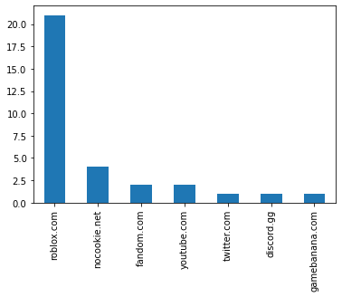

```python
if extlinks.size>0:
    extlinks.apply(lambda x: urlparse(x).netloc).str.split('.').str[-2:].str.join('.').value_counts().head(10).plot(kind='bar')
else:
    print('extlink\'nt')
```

```python
emotidex.loc[emotidex['word']=='determination']
```

|  | word | emotion | truth |
| --- | --- | --- | --- |
| 34670 | determination | anger | 0 |
| 34671 | determination | anticipation | 0 |
| 34672 | determination | disgust | 0 |
| 34673 | determination | fear | 0 |
| 34674 | determination | joy | 0 |
| 34675 | determination | negative | 0 |
| 34676 | determination | positive | 1 |
| 34677 | determination | sadness | 0 |
| 34678 | determination | surprise | 0 |
| 34679 | determination | trust | 1 |

```python
emotenum = ["anger", "anticipation", "disgust", "fear", "joy", "negative", "positive", "sadness", "surprise", "trust"]
```

```python
stopwords = open('data/englishST.txt', mode='r').read().split('\n')
stopwords
```

```
['a',
 "a's",
 'able',
 'about',
 'above',
 'according',
 'accordingly',
 'across',
 'actually',
 'after',
 'afterwards',
 'again',
 'against',
 "ain't",
 'all',
 'allow',
 'allows',
 'almost',
 'alone',
 'along',
 'already',
 'also',
 'although',
 'always',
 'am',
 'among',
 'amongst',
 'an',
 'and',
 'another',
 'any',
 'anybody',
 'anyhow',
 'anyone',
 'anything',
 'anyway',
 'anyways',
 'anywhere',
 'apart',
 'appear',
```

[output cut: 517 more lines]

```
 'y',
 'yes',
 'yet',
 'you',
 "you'd",
 "you'll",
 "you're",
 "you've",
 'your',
 'yours',
 'yourself',
 'yourselves',
 'z',
 'zero',
 '']
```

```python
def get_score(x):
    score = emotidict[i].get(x['word'])
    if score!=None:
        return score*x['words']
    else:
        return 0
```

```python
freq = final_tokens.value_counts()
newfreq = pd.DataFrame(freq.drop(index=stopwords, errors='ignore')).reset_index().rename({'index': 'word'}, axis=1)
a = []
for i in range(len(emotidict)):
    a.append(newfreq.head(500).apply(lambda x: get_score(x), axis=1).dropna().sum())
f5 = pd.DataFrame(a, columns=['freq'])
f5['emote'] = emotenum
f5
```

|  | freq | emote |
| --- | --- | --- |
| 0 | 68 | anger |
| 1 | 95 | anticipation |
| 2 | 48 | disgust |
| 3 | 91 | fear |
| 4 | 73 | joy |
| 5 | 158 | negative |
| 6 | 165 | positive |
| 7 | 54 | sadness |
| 8 | 60 | surprise |
| 9 | 132 | trust |

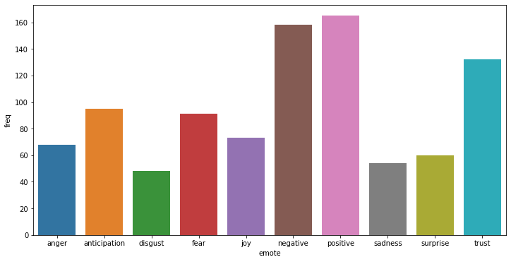

```python
plt.figure(figsize=(12,6))
sns.barplot(data=pd.DataFrame(f5), x='emote', y='freq')
```

```python
timestamp_repo = pd.read_csv('data/deltarune_timestamp_repo.csv', encoding='utf-16')
timestamp_repo
```

|  | Domain | Article | Timestamp |
| --- | --- | --- | --- |
| 0 | https://deltarune.fandom.com/api.php | ?????? | ['2022-09-28T00:09:23Z', '2022-09-18T22:07:53Z... |
| 1 | https://deltarune.fandom.com/api.php | ACT | ['2018-11-28T13:27:41Z'] |
| 2 | https://deltarune.fandom.com/api.php | Aaron | ['2021-10-11T20:36:12Z'] |
| 3 | https://deltarune.fandom.com/api.php | Abilities | ['2022-07-17T12:15:39Z'] |
| 4 | https://deltarune.fandom.com/api.php | Ability | ['2022-07-17T12:15:27Z'] |
| ... | ... | ... | ... |
| 475 | https://deltarune.fandom.com/api.php | Worm | ['2018-11-24T18:52:19Z', '2018-11-05T10:21:54Z... |
| 476 | https://deltarune.fandom.com/api.php | Wrist Protector | ['2022-07-15T04:11:44Z', '2022-07-14T23:23:41Z... |
| 477 | https://deltarune.fandom.com/api.php | Wristwatch | ['2021-10-03T18:38:09Z'] |
| 478 | https://deltarune.fandom.com/api.php | Yellow SOUL | ['2021-09-22T13:49:35Z'] |
| 479 | https://deltarune.fandom.com/api.php | Yes Man | ['2021-10-18T05:57:14Z'] |

480 rows × 3 columns

```python
time_series = pd.Series(dtype=float)
for i in range(0,timestamp_repo.shape[0]):
    time_series = pd.concat([time_series, pd.Series(json.loads(timestamp_repo.iloc[i]['Timestamp'].replace('\'', '"'))).apply(lambda x: pd.Timestamp(x))])
time_series.reset_index(drop=True, inplace=True)
```

```python
for i in range(0,timestamp_repo.shape[0]):
    time_series = pd.concat([time_series, pd.Series(json.loads(timestamp_repo.iloc[i]['Timestamp'].replace('\'', '"'))).apply(lambda x: pd.Timestamp(x))])
time_series.reset_index(drop=True, inplace=True)
```

```python
time_series
```

```
0       2022-09-28 00:09:23+00:00
1       2022-09-18 22:07:53+00:00
2       2022-09-18 22:05:12+00:00
3       2022-03-24 23:58:28+00:00
4       2022-03-16 01:13:50+00:00
                   ...
16636   2018-11-03 12:33:47+00:00
16637   2018-11-03 00:05:06+00:00
16638   2021-10-03 18:38:09+00:00
16639   2021-09-22 13:49:35+00:00
16640   2021-10-18 05:57:14+00:00
Length: 16641, dtype: datetime64[ns, UTC]
```

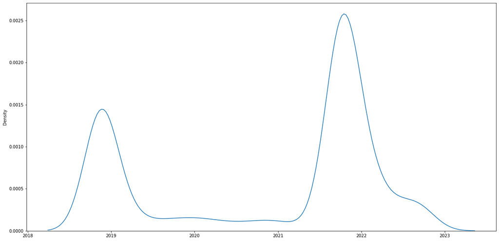

```python
plt.figure(figsize=(20,10))
sns.kdeplot(data=time_series)
```

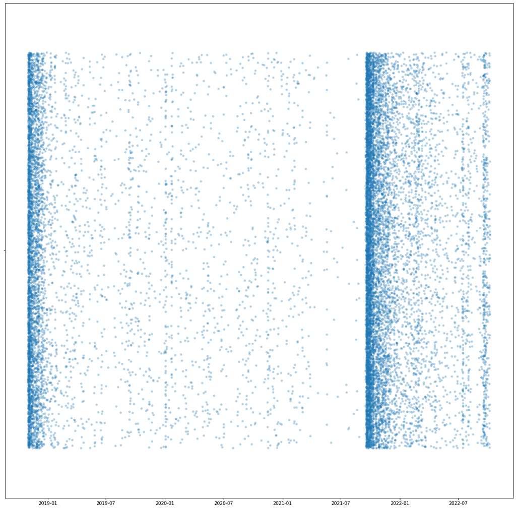

```python
fig, ax = plt.subplots(figsize=(20,20))
sns.stripplot(x = time_series, jitter=0.4)
ax.collections[0].set_alpha(0.33)
```

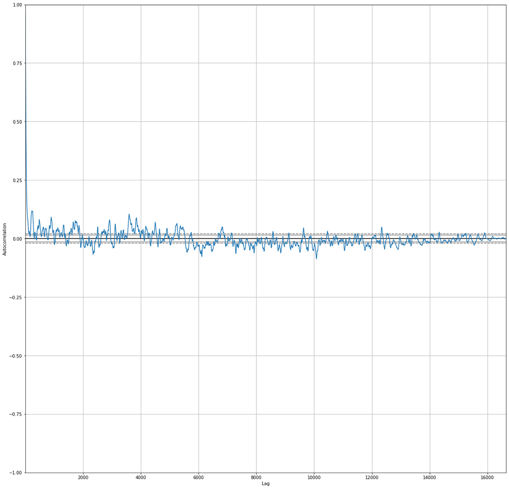

```python
fig, ax = plt.subplots(figsize=(20,20))
pd.plotting.autocorrelation_plot(time_series.apply(lambda x:x.timestamp()))
```

## References

1. https://www.opensym.org/wp-content/uploads/2018/07/OpenSym2018_paper_27.pdf Guillermo Jimenez-Diaz, Abel Serrano, Javier Arroyo: A Wikia census: motives, tools and insights
2. https://link.springer.com/chapter/10.1007/978-3-642-33460-3_55 Subhabrata Mukherjee and Pushpak Bhattacharyya: WikiSent: Weakly Supervised Sentiment Analysis through Extractive Summarization with Wikipedia

© NUS High School of Math & Science